# Modelling of the count of reported cases of Malaria in Loreto

```r
library(readr, warn.conflicts = FALSE)
library(dplyr, warn.conflicts = FALSE)
library(lubridate, warn.conflicts = FALSE)
library(dplyr, warn.conflicts = FALSE)
library(lme4, warn.conflicts = FALSE)
library(slider, warn.conflicts = FALSE)
library(gamm4, warn.conflicts = FALSE)
library(ggplot2, warn.conflicts = FALSE)
library(tictoc)
library(forecast)
library(gratia)
library(scales)
```

# Data loading

Create csv. file path.

```r
data_path <- file.path('../data/') # Data directory path
file_name <- 'dt_final.csv' # csv. file name
file_path <- file.path(data_path, file_name) # File path
```

Define data types for columns.

```r
# Column names
col_names <- c(
  "district",
  "year",
  "month",
  "falciparum",
  "vivax",
  "aet",
  "prcp",
  "q",
  "soilm",
  "tmax",
  "tmin",
  "water_deficit",
  "loss",
  "loss_km2",
  "cum_loss_km2",
  "diag",
  "enviro",
  "nets",
  "workers",
  "pamafro",
  "pop2015",
  "province",
  "region",
  "id_district"
)

# Column types
col_types <-
  readr::cols(
    district      = col_character(),
    year          = col_integer(),
    month         = col_integer(),
    falciparum    = col_integer(),
    vivax         = col_integer(),
    aet           = col_double(),
    prcp          = col_double(),
    q             = col_double(),
    soilm         = col_double(),
    tmax          = col_double(),
    tmin          = col_double(),
    water_deficit = col_double(),
    loss          = col_double(),
    loss_km2      = col_double(),
    cum_loss_km2  = col_double(),
    diag          = col_integer(),
    enviro        = col_integer(),
    nets          = col_integer(),
    workers       = col_integer(),
    pamafro       = col_integer(),
    pop2015       = col_integer(),
    province      = col_character(),
    region        = col_character(),
    id_district   = col_character()
  )
```

Reading csv. file.

```r
raw_dataset <-
  readr::read_csv(
    file      = file_path,
    col_names = col_names,
    col_types = col_types,
    skip      = 1,
    locale    = readr::locale(encoding = "utf-8")
  )
```

## Data validation

Check data structure.

```r
str(raw_dataset)
```

```
## tibble [10,584 x 24] (S3: spec_tbl_df/tbl_df/tbl/data.frame)
##  $ district     : chr [1:10584] "ALTO NANAY" "ALTO NANAY" "ALTO NANAY" "ALTO NANAY" ...
##  $ year         : int [1:10584] 2000 2000 2000 2000 2000 2000 2000 2000 2000 2000 ...
##  $ month        : int [1:10584] 1 2 3 4 5 6 7 8 9 10 ...
##  $ falciparum   : int [1:10584] 2 2 2 0 3 1 2 11 6 12 ...
##  $ vivax        : int [1:10584] 42 40 21 3 15 0 4 1 2 4 ...
##  $ aet          : num [1:10584] 90.8 82.1 66.8 61.8 70 ...
##  $ prcp         : num [1:10584] 227 278 358 334 380 ...
##  $ q            : num [1:10584] 136 196 291 272 310 ...
##  $ soilm        : num [1:10584] 35.9 35.9 35.9 35.9 35.9 ...
##  $ tmax         : num [1:10584] 31 31 30.4 30 30 ...
##  $ tmin         : num [1:10584] 21.7 21.5 21.3 20.8 21.3 ...
##  $ water_deficit: num [1:10584] 0 0 0 0 0 0 0 0 0 0 ...
##  $ loss         : num [1:10584] 0 0 0 0 0 0 0 0 0 0 ...
##  $ loss_km2     : num [1:10584] 0 0 0 0 0 0 0 0 0 0 ...
##  $ cum_loss_km2 : num [1:10584] 0 0 0 0 0 0 0 0 0 0 ...
##  $ diag         : int [1:10584] 0 0 0 0 0 0 0 0 0 0 ...
##  $ enviro       : int [1:10584] 0 0 0 0 0 0 0 0 0 0 ...
##  $ nets         : int [1:10584] 0 0 0 0 0 0 0 0 0 0 ...
##  $ workers      : int [1:10584] 0 0 0 0 0 0 0 0 0 0 ...
##  $ pamafro      : int [1:10584] 0 0 0 0 0 0 0 0 0 0 ...
##  $ pop2015      : int [1:10584] 2784 2784 2784 2784 2784 2784 2784 2784 2784 2784 ...
##  $ province     : chr [1:10584] "MAYNAS" "MAYNAS" "MAYNAS" "MAYNAS" ...
##  $ region       : chr [1:10584] "LORETO" "LORETO" "LORETO" "LORETO" ...
##  $ id_district  : chr [1:10584] "160102" "160102" "160102" "160102" ...
##  - attr(*, "spec")=
##   .. cols(
##   ..   district = col_character(),
##   ..   year = col_integer(),
##   ..   month = col_integer(),
##   ..   falciparum = col_integer(),
##   ..   vivax = col_integer(),
##   ..   aet = col_double(),
##   ..   prcp = col_double(),
##   ..   q = col_double(),
##   ..   soilm = col_double(),
##   ..   tmax = col_double(),
##   ..   tmin = col_double(),
##   ..   water_deficit = col_double(),
##   ..   loss = col_double(),
##   ..   loss_km2 = col_double(),
##   ..   cum_loss_km2 = col_double(),
##   ..   diag = col_integer(),
##   ..   enviro = col_integer(),
##   ..   nets = col_integer(),
##   ..   workers = col_integer(),
##   ..   pamafro = col_integer(),
##   ..   pop2015 = col_integer(),
##   ..   province = col_character(),
##   ..   region = col_character(),
##   ..   id_district = col_character()
##   .. )
```

Check for missing values.

```r
for (col in names(raw_dataset)) {
  cat(
    "-",
    col,
    paste(
      sum(is.na(raw_dataset[col])) / dim(raw_dataset)[1],
      "%",
      sep = ""
     ),
    "\n"
  )
}
```

```
## - district 0%
## - year 0%
## - month 0%
## - falciparum 0%
## - vivax 0%
## - aet 0%
## - prcp 0%
## - q 0%
## - soilm 0%
## - tmax 0%
## - tmin 0%
## - water_deficit 0%
## - loss 0%
## - loss_km2 0%
## - cum_loss_km2 0%
## - diag 0%
## - enviro 0%
## - nets 0%
## - workers 0%
## - pamafro 0%
## - pop2015 0%
## - province 0%
## - region 0%
## - id_district 0%
```

Check categorical features.

```r
cate_features <- c()

for (col in names(raw_dataset)) {
  if (is.character(raw_dataset[[col]])) {
    cate_features <- c(cate_features, col)
  }
}

for (col in cate_features) {
  cat(
    "-",
    col,
    length(unique(raw_dataset[[col]])),
    "\n"
  )
}
```

```
## - district 49
## - province 8
## - region 1
## - id_district 49
```

Check numerical features.

```r
num_features <- setdiff(names(raw_dataset), cate_features)

summary(raw_dataset[num_features])
```

```
##       year          month         falciparum          vivax
##  Min.   :2000   Min.   : 1.00   Min.   :   0.00   Min.   :   0.00
##  1st Qu.:2004   1st Qu.: 3.75   1st Qu.:   0.00   1st Qu.:   0.00
##  Median :2008   Median : 6.50   Median :   0.00   Median :   8.00
##  Mean   :2008   Mean   : 6.50   Mean   :  15.76   Mean   :  50.18
##  3rd Qu.:2013   3rd Qu.: 9.25   3rd Qu.:  10.00   3rd Qu.:  44.00
##  Max.   :2017   Max.   :12.00   Max.   :1240.00   Max.   :1936.00
##       aet              prcp              q                soilm
##  Min.   : 42.22   Min.   : 14.13   Min.   :  0.7085   Min.   :  8.547
##  1st Qu.: 74.34   1st Qu.:144.56   1st Qu.: 52.4859   1st Qu.: 38.876
##  Median : 82.04   Median :204.15   Median :119.4992   Median : 55.388
##  Mean   : 83.14   Mean   :222.98   Mean   :139.8399   Mean   : 70.189
##  3rd Qu.: 91.63   3rd Qu.:280.73   3rd Qu.:199.0641   3rd Qu.: 88.706
##  Max.   :118.34   Max.   :811.09   Max.   :739.0896   Max.   :207.915
##       tmax            tmin       water_deficit         loss
##  Min.   :26.90   Min.   :17.78   Min.   : 0.000   Min.   :       0
##  1st Qu.:30.70   1st Qu.:20.92   1st Qu.: 0.000   1st Qu.: 1855861
##  Median :31.44   Median :21.51   Median : 0.000   Median : 4138100
##  Mean   :31.43   Mean   :21.41   Mean   : 1.216   Mean   : 6702167
##  3rd Qu.:32.17   3rd Qu.:21.95   3rd Qu.: 0.000   3rd Qu.: 8495183
##  Max.   :35.14   Max.   :25.01   Max.   :53.384   Max.   :91853131
##     loss_km2       cum_loss_km2          diag           enviro
##  Min.   : 0.000   Min.   :  0.000   Min.   :0.000   Min.   :0.00000
##  1st Qu.: 1.856   1st Qu.:  8.221   1st Qu.:0.000   1st Qu.:0.00000
##  Median : 4.138   Median : 24.320   Median :0.000   Median :0.00000
##  Mean   : 6.702   Mean   : 46.551   Mean   :0.161   Mean   :0.07256
##  3rd Qu.: 8.495   3rd Qu.: 58.087   3rd Qu.:0.000   3rd Qu.:0.00000
##  Max.   :91.853   Max.   :689.237   Max.   :1.000   Max.   :1.00000
##       nets           workers          pamafro          pop2015
##  Min.   :0.0000   Min.   :0.0000   Min.   :0.0000   Min.   :   690
##  1st Qu.:0.0000   1st Qu.:0.0000   1st Qu.:0.0000   1st Qu.:  6017
##  Median :0.0000   Median :0.0000   Median :0.0000   Median : 10745
##  Mean   :0.0805   Mean   :0.1236   Mean   :0.2778   Mean   : 21212
##  3rd Qu.:0.0000   3rd Qu.:0.0000   3rd Qu.:1.0000   3rd Qu.: 17061
##  Max.   :1.0000   Max.   :1.0000   Max.   :1.0000   Max.   :154696
```

# Data preprocessing

Create a reporting date features in datetime format using `year` and `month` columns.

```r
dataset <-
  raw_dataset %>%
    dplyr::mutate(
      reporting_date =
        lubridate::make_datetime(
          year  = year,
          month = month,
          day   = 1L
        )
    )

dataset <-
  dataset %>%
  dplyr::arrange(reporting_date)
```

Encode `distric` and `province` as factors.

```r
dataset <-
  dataset %>%
    dplyr::mutate(
      reporting_time = as.numeric(
        factor(reporting_date),
        labels = as.character(1:length(dataset$reporting_date))
      ),
      district = factor(district),
      province = factor(province)
    )
```

Create a data frame with the start and end dates of PAMAFRO intervention.

```r
start <- lubridate::make_datetime(
  year = 2005,
  month = 10,
  day = 1L
)

end <- lubridate::make_datetime(
  year = 2010,
  month = 09,
  day = 1L
)

df_intervention_period <-
  dplyr::tibble(
    dates = c(start, end),
    type = c(
      'start',
      'end'
    )
  )
```

# Exploratory data analysis

Set `ggplot` theme.

```r
ggplot2::theme_set(theme_bw())
theme_update(panel.grid = element_blank())
```

Monthly number of malaria cases reported (x1000) in Loreto from 2000 to 2017 by parasite.

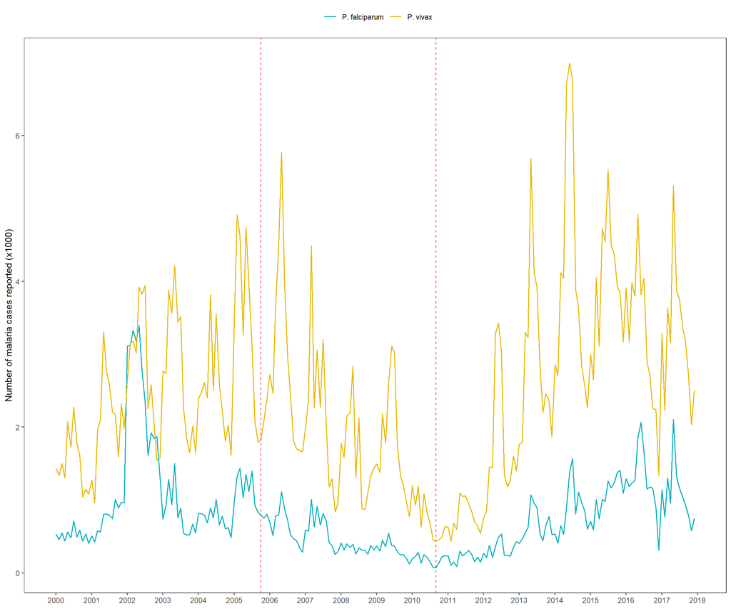

```r
dataset %>%
  dplyr::group_by(region, reporting_date) %>%
  dplyr::summarise(
    falciparum = sum(falciparum),
    vivax      = sum(vivax)
  ) %>%
  tidyr::pivot_longer(
    cols     = c(falciparum, vivax),
    names_to = "parasite"
  ) %>%
  dplyr::mutate(
    parasite = factor(
      x      = parasite,
      levels = c("falciparum", "vivax"),
      labels = c("P. falciparum", "P. vivax")
    )
  ) -> dataset_long

dataset_long %>%
  ggplot(aes(x = reporting_date, y = value / 1000)) +
  geom_line(aes(colour = parasite), size = 0.7) +
  scale_color_manual(values = c("#00AFBB", "#E7B800")) +
  geom_vline(
    data = df_intervention_period,
    aes(xintercept = as.numeric(dates)),
    linetype = "dashed",
    colour   = "red",
    alpha    = 0.8
  ) +
  scale_x_datetime(date_labels = "%Y", date_breaks = "1 year") +
  labs(y = "Number of malaria cases reported (x1000)", x = NULL) +
  theme(legend.position = "top", legend.title = element_blank())
```

Total number of malaria cases reported (x1000) in Loreto from 2000 to 2017 by parasite.

```r
dataset %>%
  summarise(
    vivax = sum(vivax),
    falciparum = sum(falciparum)
  )
```

```
## # A tibble: 1 x 2
##    vivax falciparum
##    <int>      <int>
## 1 531103     166813
```

Year-over-year percentage change of the number of malaria cases reported (x1000) in Loreto from 2000 to 2017 by parasite by parasite.

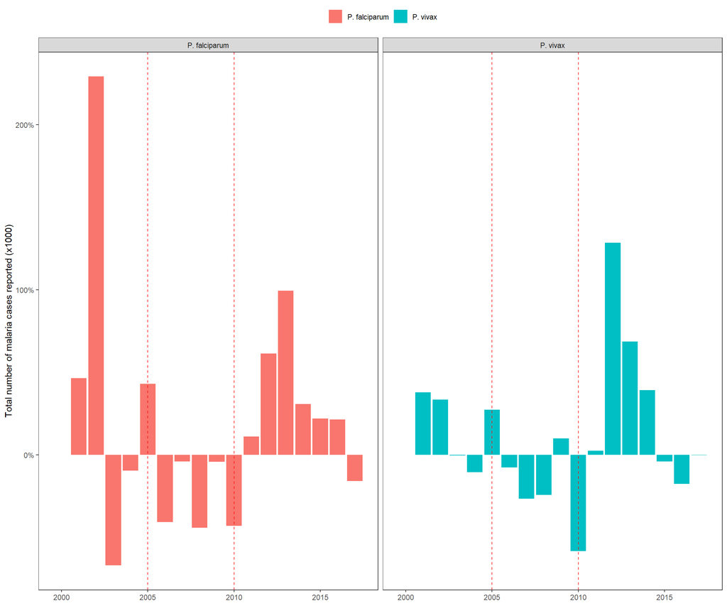

```r
dataset %>%
  dplyr::group_by(year) %>%
  dplyr::summarise(
    falciparum = sum(falciparum),
    vivax = sum(vivax)
  ) %>%
  dplyr::arrange(year) %>%
  dplyr::mutate(
    yoy_falciparum = (falciparum - lag(falciparum)) / lag(falciparum),
    yoy_vivax      = (vivax - lag(vivax)) / lag(vivax)
  ) %>%
  tidyr::pivot_longer(
    cols     = c(yoy_falciparum, yoy_vivax),
    names_to = "parasite"
  ) %>%
  dplyr::mutate(
    parasite = factor(
      x      = parasite,
      levels = c("yoy_falciparum", "yoy_vivax"),
      labels = c("P. falciparum", "P. vivax")
    )
  ) %>%
  ggplot(aes(x = year, y = value, fill = parasite)) +
  geom_col(position = "dodge") +
  scale_color_manual(values = c("#00AFBB", "#E7B800")) +
  geom_vline(
    data = tibble(dates = c(2005, 2010)),
    aes(xintercept = dates),
    linetype = "dashed",
    colour   = "red",
    alpha    = 0.8
  ) +
  scale_y_continuous(labels = scales::percent) +
  # scale_x_discrete(breaks = )
  labs(y = "Total number of malaria cases reported (x1000)", x = NULL) +
  theme(legend.position = "top", legend.title = element_blank()) +
  facet_wrap(~ parasite)
```

Top 10 district with higher MIR from 2000 to 2017

```r
dataset %>%
  dplyr::mutate(
    ir_falciparum = falciparum / pop2015,
    ir_vivax      = vivax / pop2015
  ) %>%
  dplyr::group_by(district) %>%
  dplyr::summarise(
    mir_falciparum = 1000 * mean(ir_falciparum),
    mir_vivax = 1000 * mean(ir_vivax)
  ) %>%
  dplyr::arrange(desc(mir_vivax)) %>%
  dplyr::top_n(10)
```

```
## # A tibble: 10 x 3
##    district       mir_falciparum mir_vivax
##    <fct>                   <dbl>     <dbl>
##  1 SOPLIN                  11.2      41.6
##  2 ALTO NANAY               9.58     23.5
##  3 TIGRE                    7.62     16.3
##  4 PASTAZA                  7.68     12.6
##  5 YAQUERANA                3.78     10.5
##  6 NAPO                     2.44      9.26
##  7 ALTO TAPICHE             1.13      9.23
##  8 TORRES CAUSANA           2.01      8.34
##  9 MAZAN                    3.43      8.33
## 10 TROMPETEROS              2.41      7.32
```

# Model building

## Data wrangling

### Feature scaling

Scale numerical features to have a mean = 0 and standard error = 1.

```r
cont_features <-
  c(
    "aet",
    "prcp",
    "q",
    "soilm",
    "tmax",
    "tmin"
  )

std_cont_features <-
  c(
    "aet_std",
    "prcp_std",
    "q_std",
    "soilm_std",
    "tmax_std",
    "tmin_std"
  )

dataset[, std_cont_features] <-
  scale(
    x = dataset[, cont_features],
    scale = TRUE
  )
```

### Lags

```r
dataset %>%
  dplyr::group_by(district) %>%
  dplyr::arrange(reporting_date) %>%
  dplyr::mutate(
    aet_l01    = lag(aet_std,   n = 1L),
    aet_l03    = lag(aet_std,   n = 3L),
    aet_l06    = lag(aet_std,   n = 16L),
    aet_l12    = lag(aet_std,   n = 22L),
    prcp_l01   = lag(prcp_std,  n = 1L),
    prcp_l03   = lag(prcp_std,  n = 3L),
    prcp_l06   = lag(prcp_std,  n = 16L),
    prcp_l12   = lag(prcp_std,  n = 22L),
    q_l01      = lag(q_std,     n = 1L),
    q_l03      = lag(q_std,     n = 3L),
    q_l06      = lag(q_std,     n = 16L),
    q_l12      = lag(q_std,     n = 22L),
    soilm_l01  = lag(soilm_std, n = 1L),
    soilm_l03  = lag(soilm_std, n = 3L),
    soilm_l06  = lag(soilm_std, n = 16L),
    soilm_l12  = lag(soilm_std, n = 22L),
    tmax_l01   = lag(tmax_std,  n = 1L),
    tmax_l03   = lag(tmax_std,  n = 3L),
    tmax_l06   = lag(tmax_std,  n = 16L),
    tmax_l12   = lag(tmax_std,  n = 22L),
    tmin_l01   = lag(tmin_std,  n = 1L),
    tmin_l03   = lag(tmin_std,  n = 3L),
    tmin_l06   = lag(tmin_std,  n = 16L),
    tmin_l12   = lag(tmin_std,  n = 22L)
  ) -> dataset
```

## Generalized additive models with random effects

### Vivax

Model with no lag features.

```r
tictoc::tic("GAM model fitting")
vivax_tvcm <- mgcv::bam(
  formula =
    vivax ~
    offset(log(pop2015)) +
    s(district, bs = "re", k = 49) +
    s(reporting_time, by = aet_std,   bs = "tp", k = 20) +
    s(reporting_time, by = prcp_std,  bs = "tp", k = 20) +
    s(reporting_time, by = soilm_std, bs = "tp", k = 20) +
    s(reporting_time, by = tmax_std,  bs = "tp", k = 20) +
    s(reporting_time, by = tmin_std,  bs = "tp", k = 20),
  family   = nb(),
  data     = dataset,
  method   = "fREML",
  discrete = TRUE
)
tictoc::toc()
```

```
## GAM model fitting: 3.92 sec elapsed
```

```r
vivax_tvcm$converged
```

```
## [1] TRUE
```

```r
vivax_tvcm$sp
```

```
##                 s(district)   s(reporting_time):aet_std
##                 0.271850567                 0.049971525
##  s(reporting_time):prcp_std s(reporting_time):soilm_std
##                 0.002163636                 0.011157147
##  s(reporting_time):tmax_std  s(reporting_time):tmin_std
##                 0.014243329                 0.011891258
```

```r
summary.gam(vivax_tvcm)
```

```
##
## Family: Negative Binomial(0.821)
## Link function: log
##
## Formula:
## vivax ~ offset(log(pop2015)) + s(district, bs = "re", k = 49) +
##     s(reporting_time, by = aet_std, bs = "tp", k = 20) + s(reporting_time,
##     by = prcp_std, bs = "tp", k = 20) + s(reporting_time, by = soilm_std,
##     bs = "tp", k = 20) + s(reporting_time, by = tmax_std, bs = "tp",
##     k = 20) + s(reporting_time, by = tmin_std, bs = "tp", k = 20)
##
## Parametric coefficients:
##             Estimate Std. Error t value Pr(>|t|)
## (Intercept)  -7.1266     0.2747  -25.94   <2e-16 ***
## ---
## Signif. codes:  0 '***' 0.001 '**' 0.01 '*' 0.05 '.' 0.1 ' ' 1
##
## Approximate significance of smooth terms:
##                               edf Ref.df       F p-value
## s(district)                 47.70  48.00 265.289  <2e-16 ***
## s(reporting_time):aet_std   12.98  15.27   8.396  <2e-16 ***
## s(reporting_time):prcp_std  18.91  19.78  15.426  <2e-16 ***
## s(reporting_time):soilm_std 15.38  17.55  20.382  <2e-16 ***
## s(reporting_time):tmax_std  15.31  17.35  25.349  <2e-16 ***
## s(reporting_time):tmin_std  15.90  17.90   7.651  <2e-16 ***
## ---
## Signif. codes:  0 '***' 0.001 '**' 0.01 '*' 0.05 '.' 0.1 ' ' 1
##
## R-sq.(adj) =  0.389   Deviance explained =   67%
## fREML =  15663  Scale est. = 1         n = 10584
```

```r
vivax_tvcm$aic
```

```
## [1] 74523.82
```

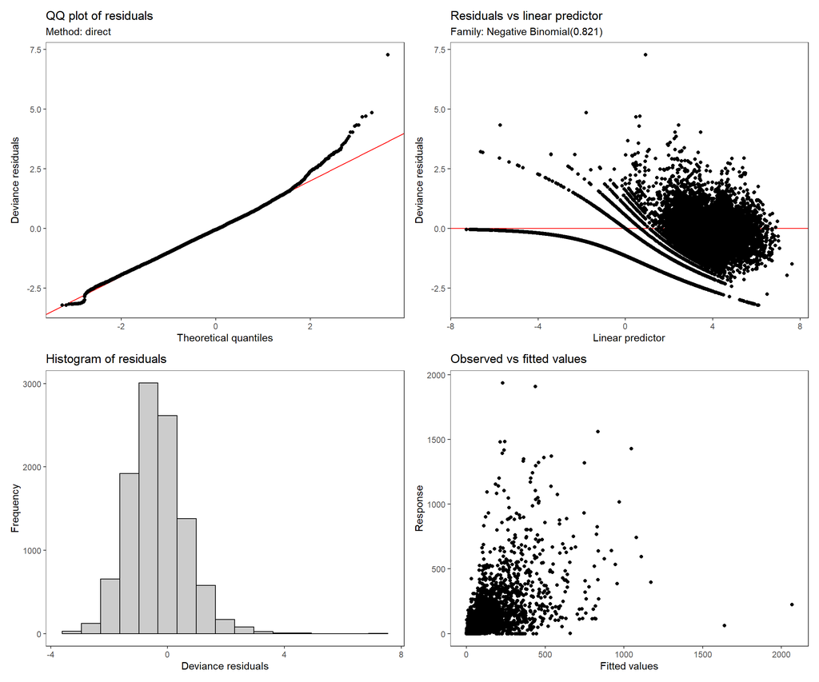

```r
appraise(vivax_tvcm)
```

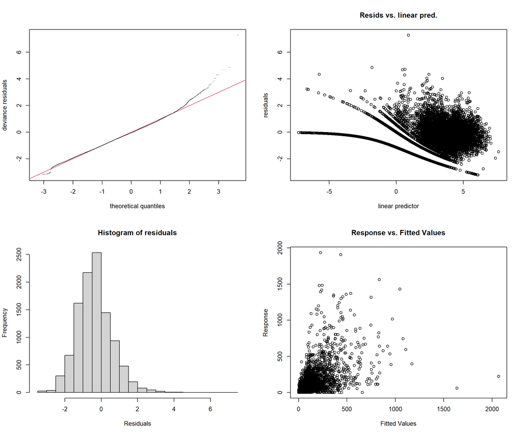

```
##
## Method: fREML   Optimizer: perf chol
## $grad
## [1] 5.908766e-08 1.835896e-07 4.209776e-08 2.088827e-07 9.288061e-08
## [6] 1.618803e-07
##
## $hess
##             [,1]         [,2]         [,3]        [,4]        [,5]        [,6]
## [1,] 21.92260025 -0.116028250  0.110074902  0.03176575 -0.07575922  0.06249723
## [2,] -0.11602825  1.127023594  0.001833438  0.07559850 -0.49254916  0.07144020
## [3,]  0.11007490  0.001833438  6.261285734  0.06074030 -0.11382749 -0.30770120
## [4,]  0.03176575  0.075598504  0.060740298  2.68536844 -0.35284042 -0.08376809
## [5,] -0.07575922 -0.492549157 -0.113827492 -0.35284042  4.47150810 -0.56033419
## [6,]  0.06249723  0.071440205 -0.307701198 -0.08376809 -0.56033419  3.59003247
##
## Model rank =  150 / 150
##
## Basis dimension (k) checking results. Low p-value (k-index<1) may
## indicate that k is too low, especially if edf is close to k'.
##
##                               k'  edf k-index p-value
## s(district)                 49.0 47.7      NA      NA
## s(reporting_time):aet_std   20.0 13.0    0.81  <2e-16 ***
## s(reporting_time):prcp_std  20.0 18.9    0.81  <2e-16 ***
## s(reporting_time):soilm_std 20.0 15.4    0.81  <2e-16 ***
## s(reporting_time):tmax_std  20.0 15.3    0.81  <2e-16 ***
## s(reporting_time):tmin_std  20.0 15.9    0.81  <2e-16 ***
## ---
## Signif. codes:  0 '***' 0.001 '**' 0.01 '*' 0.05 '.' 0.1 ' ' 1
```

```r
gam.check(vivax_tvcm)
```

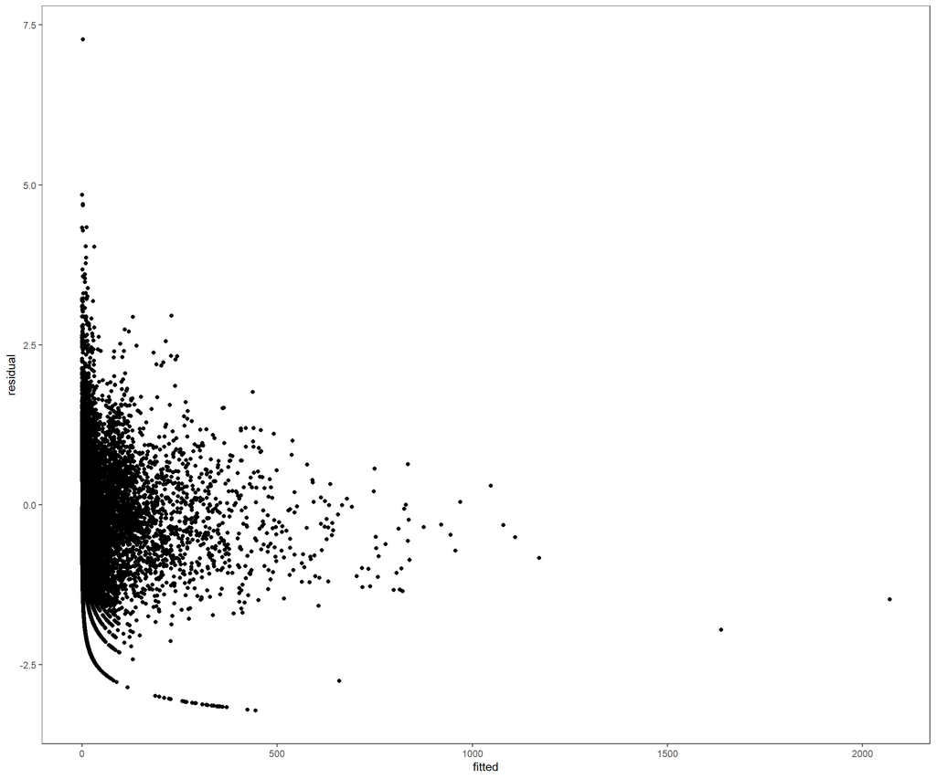

```r
tibble::tibble(
  vivax_tvcm$model,
  fitted = vivax_tvcm$fitted.values,
  residual = residuals(vivax_tvcm, type = "deviance")
) %>% ggplot(aes(x = fitted, y = residual)) + geom_point()
```

#### Distributed lag models

Model with lag = 1 month.

```r
tictoc::tic("GAM model fitting")
vivax_tvcm_l01 <- mgcv::bam(
  formula =
    vivax ~
    offset(log(pop2015)) +
    s(district, bs = "re") +
    s(reporting_time, by = aet_l01,   bs = "tp", k = 20) +
    s(reporting_time, by = prcp_l01,  bs = "tp", k = 20) +
    s(reporting_time, by = soilm_l01, bs = "tp", k = 20) +
    s(reporting_time, by = tmax_l01,  bs = "tp", k = 20) +
    s(reporting_time, by = tmin_l01,  bs = "tp", k = 20),
  family   = nb(),
  data     = dataset[!is.na(dataset$soilm_l01), ],
  method   = "fREML",
  discrete = TRUE
)
tictoc::toc()
```

```
## GAM model fitting: 3.14 sec elapsed
```

```r
vivax_tvcm_l01$converged
```

```
## [1] TRUE
```

```r
summary.gam(vivax_tvcm_l01)
```

```
##
## Family: Negative Binomial(0.811)
## Link function: log
##
## Formula:
## vivax ~ offset(log(pop2015)) + s(district, bs = "re") + s(reporting_time,
##     by = aet_l01, bs = "tp", k = 20) + s(reporting_time, by = prcp_l01,
##     bs = "tp", k = 20) + s(reporting_time, by = soilm_l01, bs = "tp",
##     k = 20) + s(reporting_time, by = tmax_l01, bs = "tp", k = 20) +
##     s(reporting_time, by = tmin_l01, bs = "tp", k = 20)
##
## Parametric coefficients:
##             Estimate Std. Error t value Pr(>|t|)
## (Intercept)  -7.0996     0.2894  -24.53   <2e-16 ***
## ---
## Signif. codes:  0 '***' 0.001 '**' 0.01 '*' 0.05 '.' 0.1 ' ' 1
##
## Approximate significance of smooth terms:
##                               edf Ref.df       F p-value
## s(district)                 47.73  48.00 263.769  <2e-16 ***
## s(reporting_time):aet_l01   11.18  13.35  10.112  <2e-16 ***
## s(reporting_time):prcp_l01  18.53  19.63  14.273  <2e-16 ***
## s(reporting_time):soilm_l01 13.39  15.71  19.949  <2e-16 ***
## s(reporting_time):tmax_l01  14.56  16.72  17.510  <2e-16 ***
## s(reporting_time):tmin_l01  15.06  17.23   9.127  <2e-16 ***
## ---
## Signif. codes:  0 '***' 0.001 '**' 0.01 '*' 0.05 '.' 0.1 ' ' 1
##
## R-sq.(adj) =  0.397   Deviance explained = 66.7%
## fREML =  15573  Scale est. = 1         n = 10535
```

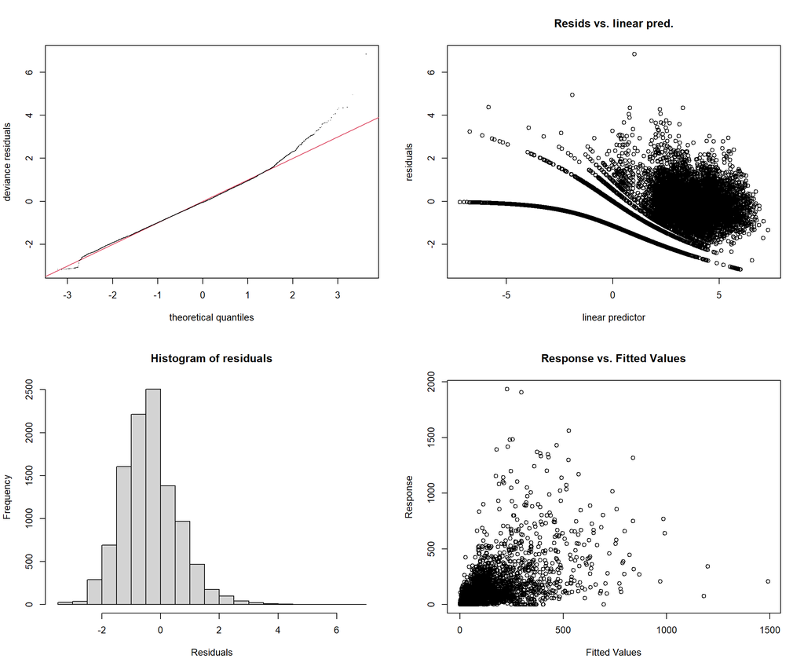

```
##
## Method: fREML   Optimizer: perf chol
## $grad
## [1] 2.134244e-07 2.720513e-07 1.102315e-07 4.005439e-07 2.077417e-07
## [6] 3.530150e-07
##
## $hess
##             [,1]        [,2]         [,3]         [,4]       [,5]        [,6]
## [1,] 21.81392733 -0.08916212  0.127172827 -0.044747288 -0.1091002 -0.05631544
## [2,] -0.08916212  1.00198849 -0.098823140  0.033413372 -0.0285051 -0.01512401
## [3,]  0.12717283 -0.09882314  6.093460256 -0.005977269 -0.1664156 -0.37435091
## [4,] -0.04474729  0.03341337 -0.005977269  2.091034060 -0.1592929  0.05841616
## [5,] -0.10910016 -0.02850510 -0.166415639 -0.159292942  3.9399406 -0.72390187
## [6,] -0.05631544 -0.01512401 -0.374350915  0.058416159 -0.7239019  3.00596497
##
## Model rank =  150 / 150
##
## Basis dimension (k) checking results. Low p-value (k-index<1) may
## indicate that k is too low, especially if edf is close to k'.
##
##                               k'  edf k-index p-value
## s(district)                 49.0 47.7      NA      NA
## s(reporting_time):aet_l01   20.0 11.2    0.76  <2e-16 ***
## s(reporting_time):prcp_l01  20.0 18.5    0.76  <2e-16 ***
## s(reporting_time):soilm_l01 20.0 13.4    0.76  <2e-16 ***
## s(reporting_time):tmax_l01  20.0 14.6    0.76  <2e-16 ***
## s(reporting_time):tmin_l01  20.0 15.1    0.76  <2e-16 ***
## ---
## Signif. codes:  0 '***' 0.001 '**' 0.01 '*' 0.05 '.' 0.1 ' ' 1
```

```r
gam.check(vivax_tvcm_l01)
```

```r
vivax_tvcm_l01$aic
```

```
## [1] 74308.73
```

Model with lag = 3 months.

```r
tictoc::tic("GAM model fitting")
vivax_tvcm_l03 <- mgcv::bam(
  formula =
    vivax ~
    offset(log(pop2015)) +
    s(district, bs = "re") +
    s(reporting_time, by = aet_l03,   bs = "tp", k = 20) +
    s(reporting_time, by = prcp_l03,  bs = "tp", k = 20) +
    s(reporting_time, by = soilm_l03, bs = "tp", k = 20) +
    s(reporting_time, by = tmax_l03,  bs = "tp", k = 20) +
    s(reporting_time, by = tmin_l03,  bs = "tp", k = 20),
  family   = nb(),
  data     = dataset[!is.na(dataset$soilm_l03), ],
  method   = "fREML",
  discrete = TRUE
)
tictoc::toc()
```

```
## GAM model fitting: 2.42 sec elapsed
```

```r
vivax_tvcm_l03$converged
```

```
## [1] TRUE
```

```r
summary.gam(vivax_tvcm_l03)
```

```
##
## Family: Negative Binomial(0.82)
## Link function: log
##
## Formula:
## vivax ~ offset(log(pop2015)) + s(district, bs = "re") + s(reporting_time,
##     by = aet_l03, bs = "tp", k = 20) + s(reporting_time, by = prcp_l03,
##     bs = "tp", k = 20) + s(reporting_time, by = soilm_l03, bs = "tp",
##     k = 20) + s(reporting_time, by = tmax_l03, bs = "tp", k = 20) +
##     s(reporting_time, by = tmin_l03, bs = "tp", k = 20)
##
## Parametric coefficients:
##             Estimate Std. Error t value Pr(>|t|)
## (Intercept)  -7.0671     0.2847  -24.82   <2e-16 ***
## ---
## Signif. codes:  0 '***' 0.001 '**' 0.01 '*' 0.05 '.' 0.1 ' ' 1
##
## Approximate significance of smooth terms:
##                                edf Ref.df       F p-value
## s(district)                 47.722 48.000 268.866  <2e-16 ***
## s(reporting_time):aet_l03    8.202  9.914   7.836  <2e-16 ***
## s(reporting_time):prcp_l03  15.248 17.386  27.103  <2e-16 ***
## s(reporting_time):soilm_l03 14.236 16.566  18.641  <2e-16 ***
## s(reporting_time):tmax_l03  11.146 13.264  16.271  <2e-16 ***
## s(reporting_time):tmin_l03  13.772 16.059  10.456  <2e-16 ***
## ---
## Signif. codes:  0 '***' 0.001 '**' 0.01 '*' 0.05 '.' 0.1 ' ' 1
##
## R-sq.(adj) =  0.405   Deviance explained =   67%
## fREML =  15400  Scale est. = 1         n = 10437
```

```r
vivax_tvcm_l03$aic
```

```
## [1] 73597.26
```

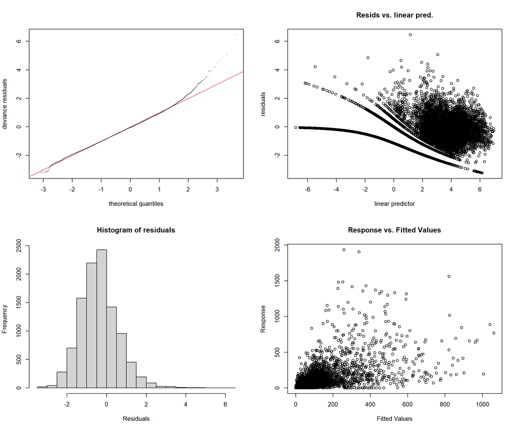

```
##
## Method: fREML   Optimizer: perf chol
## $grad
## [1] 3.620340e-08 2.537108e-08 2.717467e-08 4.693478e-08 3.785714e-08
## [6] 5.698151e-08
##
## $hess
##             [,1]        [,2]        [,3]       [,4]        [,5]        [,6]
## [1,] 22.04510676 -0.08192821  0.13035278 -0.1029670 -0.14688535 -0.11655136
## [2,] -0.08192821  1.02226928 -0.01378155  0.0744201 -0.01102963  0.03827119
## [3,]  0.13035278 -0.01378155  3.14127007  0.1778233 -0.41610398 -0.35171650
## [4,] -0.10296697  0.07442010  0.17782327  2.5147822  0.15664588  0.34454094
## [5,] -0.14688535 -0.01102963 -0.41610398  0.1566459  2.11992474 -0.54167130
## [6,] -0.11655136  0.03827119 -0.35171650  0.3445409 -0.54167130  2.39940155
##
## Model rank =  150 / 150
##
## Basis dimension (k) checking results. Low p-value (k-index<1) may
## indicate that k is too low, especially if edf is close to k'.
##
##                               k'  edf k-index p-value
## s(district)                 49.0 47.7      NA      NA
## s(reporting_time):aet_l03   20.0  8.2    0.79  <2e-16 ***
## s(reporting_time):prcp_l03  20.0 15.2    0.79  <2e-16 ***
## s(reporting_time):soilm_l03 20.0 14.2    0.79  <2e-16 ***
## s(reporting_time):tmax_l03  20.0 11.2    0.79  <2e-16 ***
## s(reporting_time):tmin_l03  20.0 13.8    0.79  <2e-16 ***
## ---
## Signif. codes:  0 '***' 0.001 '**' 0.01 '*' 0.05 '.' 0.1 ' ' 1
```

```r
gam.check(vivax_tvcm_l03)
```

```r
tictoc::tic("GAM model fitting")
vivax_tvcm_l06 <- mgcv::bam(
  formula =
    vivax ~
    offset(log(pop2015)) +
    s(district, bs = "re") +
    s(reporting_time, by = aet_l06,   bs = "tp", k = 20) +
    s(reporting_time, by = prcp_l06,  bs = "tp", k = 20) +
    s(reporting_time, by = soilm_l06, bs = "tp", k = 20) +
    s(reporting_time, by = tmax_l06,  bs = "tp", k = 20) +
    s(reporting_time, by = tmin_l06,  bs = "tp", k = 20),
  family   = nb(),
  data     = dataset[!is.na(dataset$soilm_l06), ],
  method   = "fREML",
  discrete = TRUE
)
tictoc::toc()
```

```
## GAM model fitting: 2.38 sec elapsed
```

```r
vivax_tvcm_l06$converged
```

```
## [1] TRUE
```

```r
summary.gam(vivax_tvcm_l06)
```

```
##
## Family: Negative Binomial(0.857)
## Link function: log
##
## Formula:
## vivax ~ offset(log(pop2015)) + s(district, bs = "re") + s(reporting_time,
##     by = aet_l06, bs = "tp", k = 20) + s(reporting_time, by = prcp_l06,
##     bs = "tp", k = 20) + s(reporting_time, by = soilm_l06, bs = "tp",
##     k = 20) + s(reporting_time, by = tmax_l06, bs = "tp", k = 20) +
##     s(reporting_time, by = tmin_l06, bs = "tp", k = 20)
##
## Parametric coefficients:
##             Estimate Std. Error t value Pr(>|t|)
## (Intercept)  -7.0178     0.2985  -23.51   <2e-16 ***
## ---
## Signif. codes:  0 '***' 0.001 '**' 0.01 '*' 0.05 '.' 0.1 ' ' 1
##
## Approximate significance of smooth terms:
##                               edf Ref.df       F p-value
## s(district)                 47.74  48.00 266.785  <2e-16 ***
## s(reporting_time):aet_l06   15.31  17.46   8.108  <2e-16 ***
## s(reporting_time):prcp_l06  13.40  15.66  31.846  <2e-16 ***
## s(reporting_time):soilm_l06 16.08  18.09  17.874  <2e-16 ***
## s(reporting_time):tmax_l06  18.20  19.36  12.803  <2e-16 ***
## s(reporting_time):tmin_l06  15.21  17.33   6.621  <2e-16 ***
## ---
## Signif. codes:  0 '***' 0.001 '**' 0.01 '*' 0.05 '.' 0.1 ' ' 1
##
## R-sq.(adj) =  0.422   Deviance explained = 68.2%
## fREML =  14537  Scale est. = 1         n = 9800
```

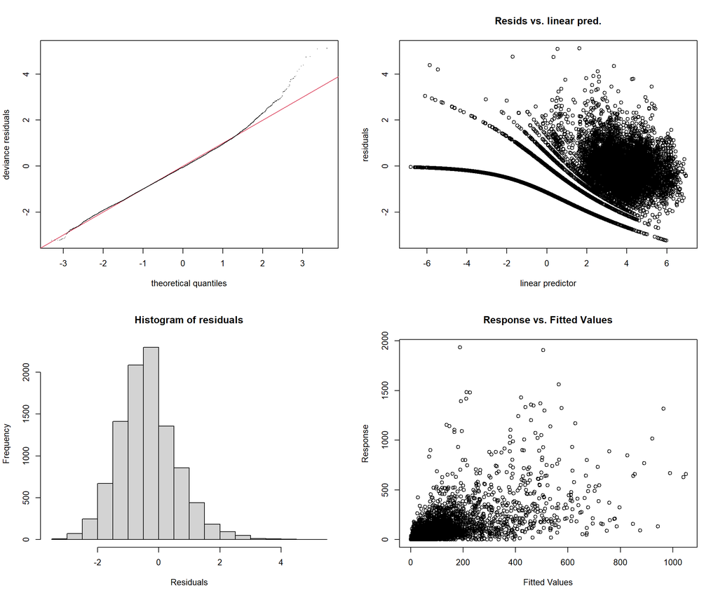

```
##
## Method: fREML   Optimizer: perf chol
## $grad
## [1] -7.583580e-08 -3.468841e-08 -2.001398e-08 -1.217720e-07 -5.702185e-08
## [6] -1.142597e-07
##
## $hess
##             [,1]        [,2]        [,3]         [,4]         [,5]       [,6]
## [1,] 22.04440250  0.01750394  0.10445418 -0.159485874  0.023596591 -0.0998737
## [2,]  0.01750394  3.68154941 -0.09745369 -0.177605690  0.559862554 -0.2080835
## [3,]  0.10445418 -0.09745369  3.64361464 -0.047709885 -0.079385899 -0.1718232
## [4,] -0.15948587 -0.17760569 -0.04770989  3.157667480 -0.008605285  0.4568989
## [5,]  0.02359659  0.55986255 -0.07938590 -0.008605285  4.261990111  0.8006907
## [6,] -0.09987370 -0.20808346 -0.17182316  0.456898895  0.800690693  1.9011886
##
## Model rank =  150 / 150
##
## Basis dimension (k) checking results. Low p-value (k-index<1) may
## indicate that k is too low, especially if edf is close to k'.
##
##                               k'  edf k-index p-value
## s(district)                 49.0 47.7      NA      NA
## s(reporting_time):aet_l06   20.0 15.3    0.79  <2e-16 ***
## s(reporting_time):prcp_l06  20.0 13.4    0.79  <2e-16 ***
## s(reporting_time):soilm_l06 20.0 16.1    0.79  <2e-16 ***
## s(reporting_time):tmax_l06  20.0 18.2    0.79  <2e-16 ***
## s(reporting_time):tmin_l06  20.0 15.2    0.79  <2e-16 ***
## ---
## Signif. codes:  0 '***' 0.001 '**' 0.01 '*' 0.05 '.' 0.1 ' ' 1
```

```r
gam.check(vivax_tvcm_l06)
```

```r
tictoc::tic("GAM model fitting")
vivax_tvcm_l12 <- mgcv::bam(
  formula =
    vivax ~
    offset(log(pop2015)) +
    s(district, bs = "re") +
    s(reporting_time, by = aet_l12,   bs = "tp", k = 20) +
    s(reporting_time, by = prcp_l12,  bs = "tp", k = 20) +
    s(reporting_time, by = soilm_l12, bs = "tp", k = 20) +
    s(reporting_time, by = tmax_l12,  bs = "tp", k = 20) +
    s(reporting_time, by = tmin_l12,  bs = "tp", k = 20),
  family   = nb(),
  data     = dataset[!is.na(dataset$soilm_l12), ],
  method   = "fREML",
  discrete = TRUE
)
tictoc::toc()
```

```
## GAM model fitting: 3.7 sec elapsed
```

```r
vivax_tvcm_l12$converged
```

```
## [1] TRUE
```

```r
summary.gam(vivax_tvcm_l12)
```

```
##
## Family: Negative Binomial(0.887)
## Link function: log
##
## Formula:
## vivax ~ offset(log(pop2015)) + s(district, bs = "re") + s(reporting_time,
##     by = aet_l12, bs = "tp", k = 20) + s(reporting_time, by = prcp_l12,
##     bs = "tp", k = 20) + s(reporting_time, by = soilm_l12, bs = "tp",
##     k = 20) + s(reporting_time, by = tmax_l12, bs = "tp", k = 20) +
##     s(reporting_time, by = tmin_l12, bs = "tp", k = 20)
##
## Parametric coefficients:
##             Estimate Std. Error t value Pr(>|t|)
## (Intercept)  -7.0922     0.2887  -24.57   <2e-16 ***
## ---
## Signif. codes:  0 '***' 0.001 '**' 0.01 '*' 0.05 '.' 0.1 ' ' 1
##
## Approximate significance of smooth terms:
##                               edf Ref.df       F p-value
## s(district)                 47.73  48.00 262.312  <2e-16 ***
## s(reporting_time):aet_l12   15.05  17.22  13.172  <2e-16 ***
## s(reporting_time):prcp_l12  14.65  16.86   9.998  <2e-16 ***
## s(reporting_time):soilm_l12 16.61  18.48  24.359  <2e-16 ***
## s(reporting_time):tmax_l12  16.86  18.56  18.064  <2e-16 ***
## s(reporting_time):tmin_l12  15.99  17.95   8.782  <2e-16 ***
## ---
## Signif. codes:  0 '***' 0.001 '**' 0.01 '*' 0.05 '.' 0.1 ' ' 1
##
## R-sq.(adj) =  0.462   Deviance explained = 69.1%
## fREML =  14126  Scale est. = 1         n = 9506
```

```r
vivax_tvcm_l12$aic
```

```
## [1] 67659.98
```

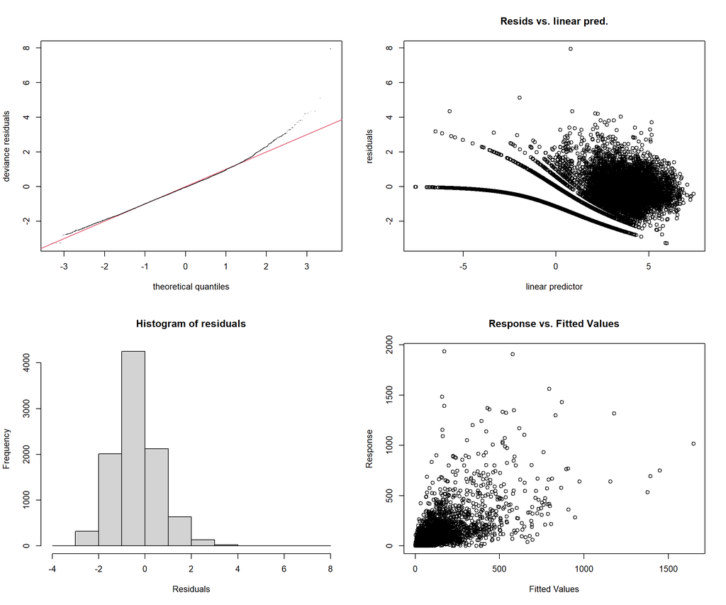

```
##
## Method: fREML   Optimizer: perf chol
## $grad
## [1] -7.824148e-09  1.390967e-10  4.230834e-08 -6.940892e-09 -2.480643e-09
## [6]  2.212552e-08
##
## $hess
##             [,1]         [,2]        [,3]        [,4]       [,5]         [,6]
## [1,] 21.92786600  0.028338822 -0.02170076 -0.09498352 -0.2755716 -0.137409469
## [2,]  0.02833882  2.703167234 -0.34872172  0.09368010 -0.0175219 -0.007773273
## [3,] -0.02170076 -0.348721716  1.90860302 -0.08308559 -0.1486962 -0.143758259
## [4,] -0.09498352  0.093680099 -0.08308559  4.76834886  0.3160813 -0.720069768
## [5,] -0.27557160 -0.017521898 -0.14869622  0.31608133  1.4424985  0.792251590
## [6,] -0.13740947 -0.007773273 -0.14375826 -0.72006977  0.7922516  3.864043510
##
## Model rank =  150 / 150
##
## Basis dimension (k) checking results. Low p-value (k-index<1) may
## indicate that k is too low, especially if edf is close to k'.
##
##                               k'  edf k-index p-value
## s(district)                 49.0 47.7      NA      NA
## s(reporting_time):aet_l12   20.0 15.1    0.82  <2e-16 ***
## s(reporting_time):prcp_l12  20.0 14.7    0.82  <2e-16 ***
## s(reporting_time):soilm_l12 20.0 16.6    0.82  <2e-16 ***
## s(reporting_time):tmax_l12  20.0 16.9    0.82  <2e-16 ***
## s(reporting_time):tmin_l12  20.0 16.0    0.82  <2e-16 ***
## ---
## Signif. codes:  0 '***' 0.001 '**' 0.01 '*' 0.05 '.' 0.1 ' ' 1
```

```r
gam.check(vivax_tvcm_l12)
```

Model with all the lag features.

```r
tictoc::tic("GAM model fitting")
vivax_tvcm_l <- mgcv::bam(
  formula =
    vivax ~
    offset(log(pop2015)) +
    s(district, bs = "re") +
    s(reporting_time, by = aet_l01,   bs = "tp", k = 20) +
    s(reporting_time, by = aet_l03,   bs = "tp", k = 20) +
    s(reporting_time, by = aet_l06,   bs = "tp", k = 20) +
    s(reporting_time, by = aet_l12,   bs = "tp", k = 20) +
    s(reporting_time, by = prcp_l01,  bs = "tp", k = 20) +
    s(reporting_time, by = prcp_l03,  bs = "tp", k = 20) +
    s(reporting_time, by = prcp_l06,  bs = "tp", k = 20) +
    s(reporting_time, by = prcp_l12,  bs = "tp", k = 20) +
    s(reporting_time, by = soilm_l01, bs = "tp", k = 20) +
    s(reporting_time, by = soilm_l03, bs = "tp", k = 20) +
    s(reporting_time, by = soilm_l06, bs = "tp", k = 20) +
    s(reporting_time, by = soilm_l12, bs = "tp", k = 20) +
    s(reporting_time, by = tmax_l01,  bs = "tp", k = 20) +
    s(reporting_time, by = tmax_l03,  bs = "tp", k = 20) +
    s(reporting_time, by = tmax_l06,  bs = "tp", k = 20) +
    s(reporting_time, by = tmax_l12,  bs = "tp", k = 20) +
    s(reporting_time, by = tmin_l01,  bs = "tp", k = 20) +
    s(reporting_time, by = tmin_l03,  bs = "tp", k = 20) +
    s(reporting_time, by = tmin_l06,  bs = "tp", k = 20) +
    s(reporting_time, by = tmin_l12,  bs = "tp", k = 20),
  family   = nb(),
  data     = dataset[!is.na(dataset$soilm_l12), ],
  method   = "fREML",
  discrete = TRUE
)
tictoc::toc()
```

```
## GAM model fitting: 8.61 sec elapsed
```

```r
vivax_tvcm_l$converged
```

```
## [1] TRUE
```

```r
summary(vivax_tvcm_l)
```

```
##
## Family: Negative Binomial(1.05)
## Link function: log
##
## Formula:
## vivax ~ offset(log(pop2015)) + s(district, bs = "re") + s(reporting_time,
##     by = aet_l01, bs = "tp", k = 20) + s(reporting_time, by = aet_l03,
##     bs = "tp", k = 20) + s(reporting_time, by = aet_l06, bs = "tp",
##     k = 20) + s(reporting_time, by = aet_l12, bs = "tp", k = 20) +
##     s(reporting_time, by = prcp_l01, bs = "tp", k = 20) + s(reporting_time,
##     by = prcp_l03, bs = "tp", k = 20) + s(reporting_time, by = prcp_l06,
##     bs = "tp", k = 20) + s(reporting_time, by = prcp_l12, bs = "tp",
##     k = 20) + s(reporting_time, by = soilm_l01, bs = "tp", k = 20) +
##     s(reporting_time, by = soilm_l03, bs = "tp", k = 20) + s(reporting_time,
##     by = soilm_l06, bs = "tp", k = 20) + s(reporting_time, by = soilm_l12,
##     bs = "tp", k = 20) + s(reporting_time, by = tmax_l01, bs = "tp",
##     k = 20) + s(reporting_time, by = tmax_l03, bs = "tp", k = 20) +
##     s(reporting_time, by = tmax_l06, bs = "tp", k = 20) + s(reporting_time,
##     by = tmax_l12, bs = "tp", k = 20) + s(reporting_time, by = tmin_l01,
##     bs = "tp", k = 20) + s(reporting_time, by = tmin_l03, bs = "tp",
##     k = 20) + s(reporting_time, by = tmin_l06, bs = "tp", k = 20) +
##     s(reporting_time, by = tmin_l12, bs = "tp", k = 20)
##
## Parametric coefficients:
##             Estimate Std. Error t value Pr(>|t|)
## (Intercept)  -7.1435     0.2407  -29.67   <2e-16 ***
## ---
## Signif. codes:  0 '***' 0.001 '**' 0.01 '*' 0.05 '.' 0.1 ' ' 1
##
## Approximate significance of smooth terms:
##                                edf Ref.df       F  p-value
## s(district)                 47.348 48.000 283.977  < 2e-16 ***
## s(reporting_time):aet_l01   12.298 14.377   4.756  < 2e-16 ***
## s(reporting_time):aet_l03    5.679  6.758   3.747 0.000504 ***
## s(reporting_time):aet_l06   13.657 15.783   5.478  < 2e-16 ***
## s(reporting_time):aet_l12   14.162 16.240   6.278  < 2e-16 ***
## s(reporting_time):prcp_l01  15.597 17.551   5.587  < 2e-16 ***
## s(reporting_time):prcp_l03   8.287  9.925  12.991  < 2e-16 ***
## s(reporting_time):prcp_l06  10.838 12.852  13.509  < 2e-16 ***
## s(reporting_time):prcp_l12  12.373 14.528   8.690  < 2e-16 ***
## s(reporting_time):soilm_l01  9.579 11.259   2.102 0.025149 *
## s(reporting_time):soilm_l03  2.000  2.000   8.250 0.000264 ***
## s(reporting_time):soilm_l06  2.000  2.000   7.301 0.000678 ***
## s(reporting_time):soilm_l12  8.816 10.376   5.041  < 2e-16 ***
## s(reporting_time):tmax_l01   6.533  7.763   9.285  < 2e-16 ***
## s(reporting_time):tmax_l03   5.938  7.081   4.267 9.93e-05 ***
## s(reporting_time):tmax_l06   5.229  6.204   5.813 4.77e-06 ***
## s(reporting_time):tmax_l12  14.414 16.462  10.790  < 2e-16 ***
## s(reporting_time):tmin_l01   4.479  5.301   6.183 8.57e-06 ***
## s(reporting_time):tmin_l03  15.321 17.287   4.427  < 2e-16 ***
## s(reporting_time):tmin_l06  11.456 13.459   5.885  < 2e-16 ***
## s(reporting_time):tmin_l12  10.034 11.904   7.418  < 2e-16 ***
## ---
## Signif. codes:  0 '***' 0.001 '**' 0.01 '*' 0.05 '.' 0.1 ' ' 1
##
## R-sq.(adj) =  0.519   Deviance explained = 73.2%
## fREML =  14347  Scale est. = 1         n = 9506
```

```r
vivax_tvcm_l$aic
```

```
## [1] 66631.12
```

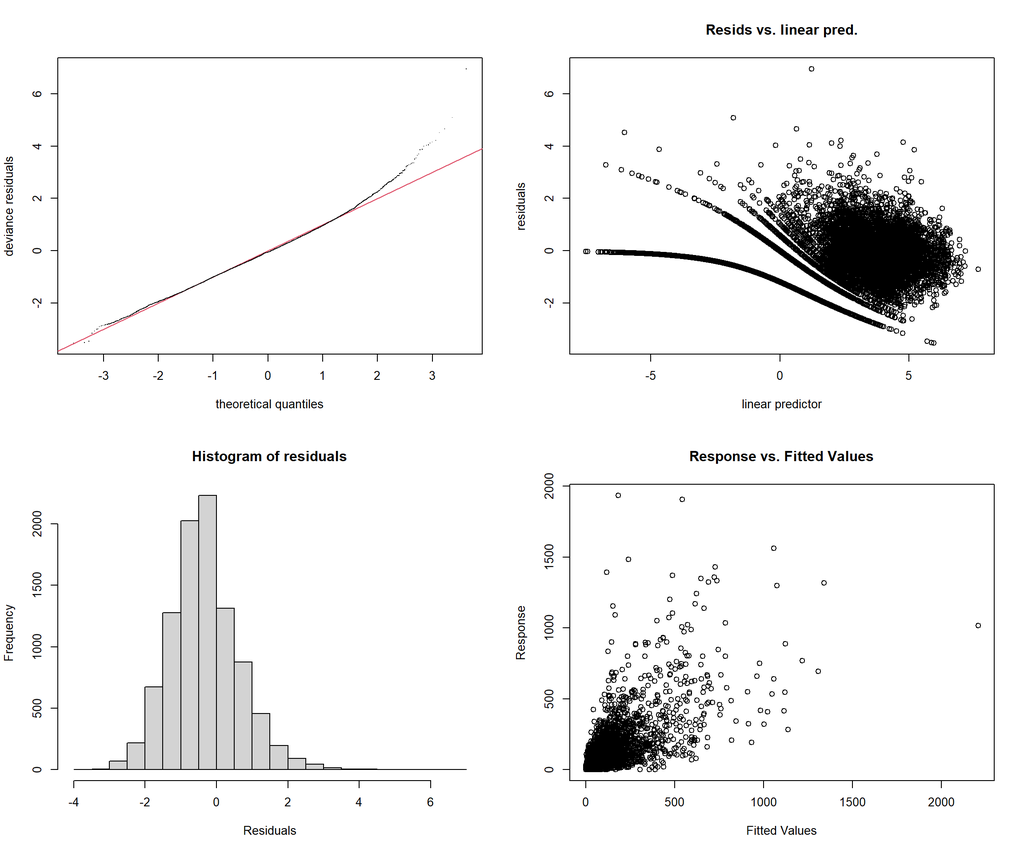

```
##
## Method: fREML   Optimizer: perf chol
## $grad
##  [1] -1.733137e-06 -1.313973e-06 -1.219672e-07  4.775909e-06  5.015313e-07
##  [6] -9.212855e-06 -4.512340e-06  4.627494e-06 -1.609982e-06 -4.751365e-08
## [11] -5.511287e-05 -3.438799e-05  1.605975e-05  9.801661e-07  2.103639e-06
## [16] -2.643354e-06  3.717854e-06  1.268645e-06  5.024351e-06 -1.657483e-06
## [21]  1.389702e-06
##
## $hess
##                [,1]          [,2]          [,3]          [,4]          [,5]
##  [1,]  2.186380e+01  6.762685e-02 -1.622858e-02  4.090200e-02 -3.352581e-02
##  [2,]  6.762685e-02  1.414246e+00  1.193938e-01 -1.678681e-01 -2.969579e-01
##  [3,] -1.622858e-02  1.193938e-01  9.024862e-01  6.934421e-03  7.970046e-02
##  [4,]  4.090200e-02 -1.678681e-01  6.934421e-03  3.851293e+00 -8.714505e-02
```

[output cut: 135 more lines]

```r
gam.check(vivax_tvcm_l)
```

#### Time-varying coefficients plots

```r
plot_tvcm <- function(plot, labels, ylim) {
  n_plots <- length(plot)
  dfs <-  vector(mode = "list", length = n_plots - 1)

  for (i in 2:n_plots) {
    dfs[[(i-1)]] <-
      tibble::tibble(
        x    = plot[[i]]$x,
        se   = plot[[i]]$se,
        fit  = plot[[i]]$fit,
        term = labels[(i-1)]
      )
  }

  df <- dplyr::bind_rows(dfs)
  df$term <- factor(df$term, labels)

  tvc_plot <- ggplot(
    data = df,
    aes(x = x, y = fit)
  )

  tvc_plot +
    geom_line(aes(y = fit)) +
    geom_ribbon(
      aes(
        ymin = fit + se,
        ymax = fit - se
      ),
      fill  = "grey70",
      alpha = 0.7
    ) +
    geom_vline(
      data = tibble(dates = c(70, 129)),
      aes(xintercept = dates),
      linetype = "dashed",
      colour   = "red"
    ) +
    geom_hline(
      aes(yintercept = 0),
      linetype = "dashed",
      alpha = 0.6
    ) +
    scale_y_continuous(limits = ylim, n.breaks = 9) +
    scale_x_continuous(limits = c(1, 216), n.breaks = 5) +
    geom_rug(sides = "b") +
    facet_wrap(~ term, ncol = 2) +
    ylab("b(t)") +
    xlab("Reporting time")
}
```

Model with no lag features.

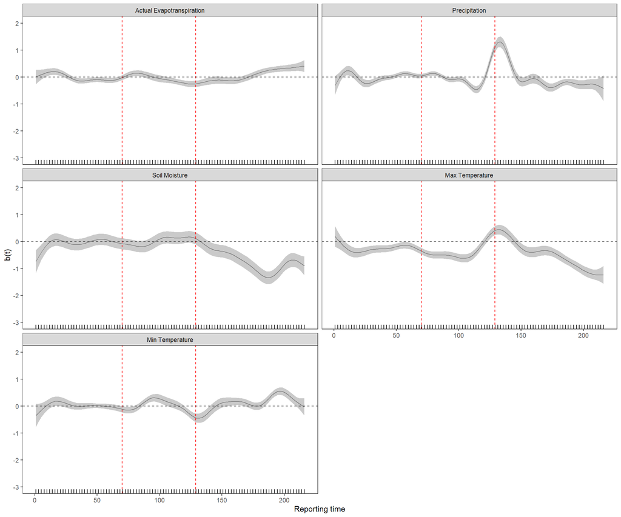

```r
vivax_ylim <- c(-1.6, 1.6)

vivax_tvcm_labels <- c(
    "Actual Evapotranspiration",
    "Precipitation",
    "Soil Moisture",
    "Max Temperature",
    "Min Temperature"
  )

plot_tvcm(plot_vivax_tvcm, vivax_tvcm_labels, c(-3, 2))
```

Model with lag = 1 month.

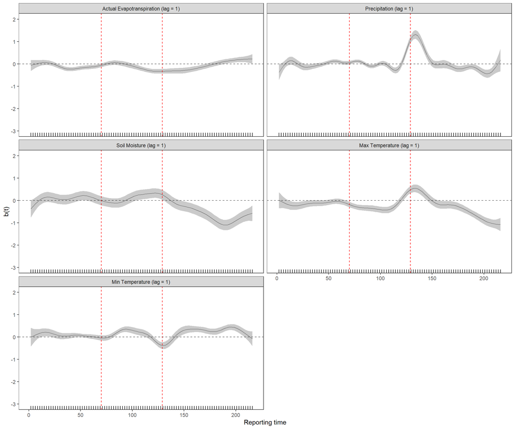

```r
vivax_tvcm_l01_labels <- c(
    "Actual Evapotranspiration (lag = 1)",
    "Precipitation (lag = 1)",
    "Soil Moisture (lag = 1)",
    "Max Temperature (lag = 1)",
    "Min Temperature (lag = 1)"
  )

plot_tvcm(plot_vivax_tvcm_l01, vivax_tvcm_l01_labels, c(-3, 2))
```

Model with lag = 3 months.

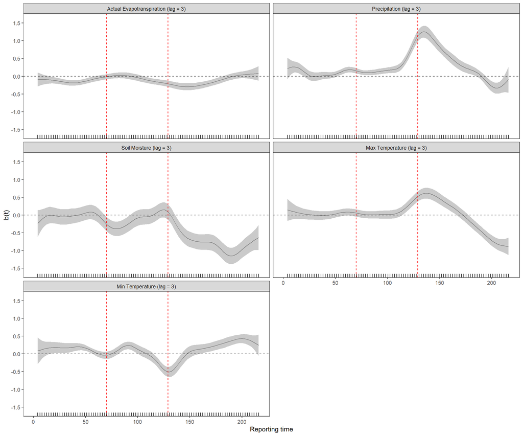

```r
vivax_tvcm_l03_labels <- c(
    "Actual Evapotranspiration (lag = 3)",
    "Precipitation (lag = 3)",
    "Soil Moisture (lag = 3)",
    "Max Temperature (lag = 3)",
    "Min Temperature (lag = 3)"
  )

plot_tvcm(plot_vivax_tvcm_l03, vivax_tvcm_l03_labels, vivax_ylim)
```

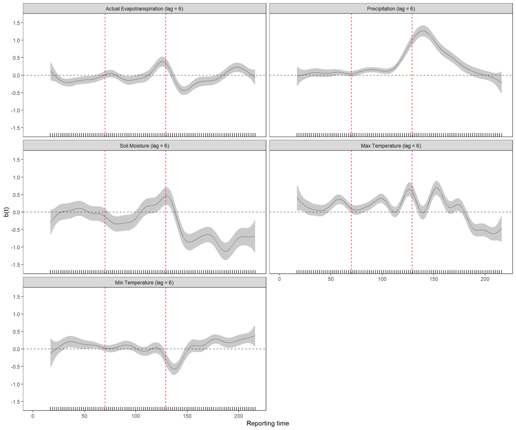

```r
vivax_tvcm_l06_labels <- c(
    "Actual Evapotranspiration (lag = 6)",
    "Precipitation (lag = 6)",
    "Soil Moisture (lag = 6)",
    "Max Temperature (lag = 6)",
    "Min Temperature (lag = 6)"
  )

plot_tvcm(plot_vivax_tvcm_l06, vivax_tvcm_l06_labels, vivax_ylim)
```

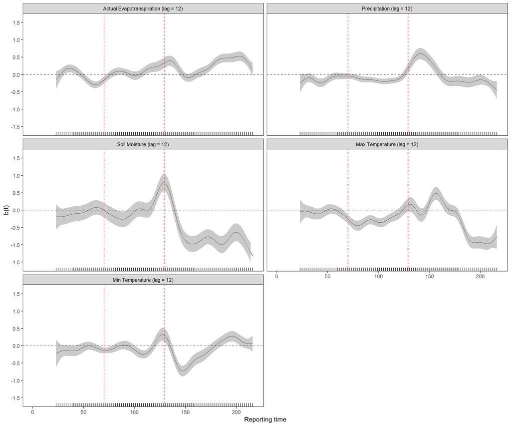

```r
vivax_tvcm_l12_labels <- c(
    "Actual Evapotranspiration (lag = 12)",
    "Precipitation (lag = 12)",
    "Soil Moisture (lag = 12)",
    "Max Temperature (lag = 12)",
    "Min Temperature (lag = 12)"
  )

plot_tvcm(plot_vivax_tvcm_l12, vivax_tvcm_l12_labels, vivax_ylim)
```

Model with all the lag features.

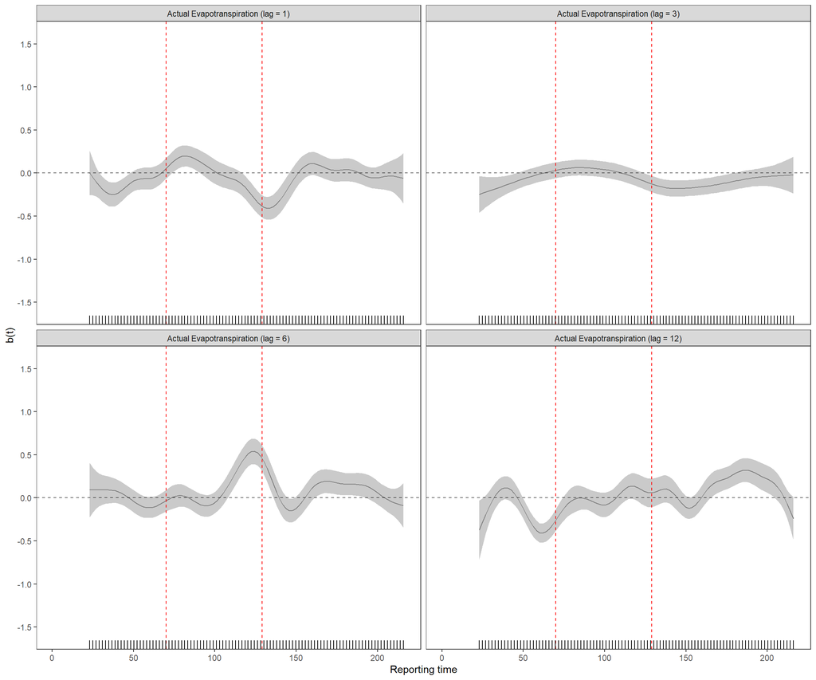

```r
vivax_tvcm_l_labels <- c(
    "Actual Evapotranspiration (lag = 1)",
    "Actual Evapotranspiration (lag = 3)",
    "Actual Evapotranspiration (lag = 6)",
    "Actual Evapotranspiration (lag = 12)",
    "Precipitation (lag = 1)",
    "Precipitation (lag = 3)",
    "Precipitation (lag = 6)",
    "Precipitation (lag = 12)",
    "Soil Moisture (lag = 1)",
    "Soil Moisture (lag = 3)",
    "Soil Moisture (lag = 6)",
    "Soil Moisture (lag = 12)",
    "Max Temperature (lag = 1)",
    "Max Temperature (lag = 3)",
    "Max Temperature (lag = 6)",
    "Max Temperature (lag = 12)",
    "Min Temperature (lag = 1)",
    "Min Temperature (lag = 3)",
    "Min Temperature (lag = 6)",
    "Min Temperature (lag = 12)"
  )

plot_tvcm(plot_vivax_tvcm_l[1:5], vivax_tvcm_l_labels[1:5], vivax_ylim)
```

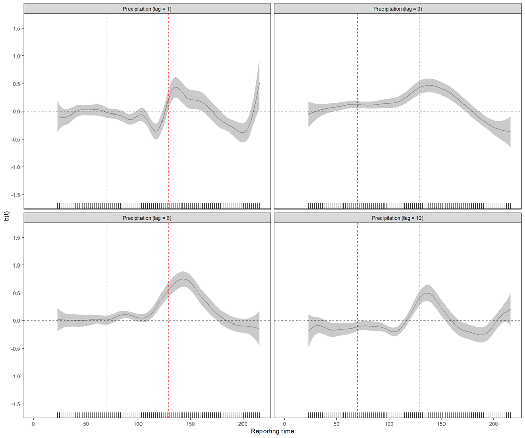

```r
plot_tvcm(plot_vivax_tvcm_l[5:9], vivax_tvcm_l_labels[5:9], vivax_ylim)
```

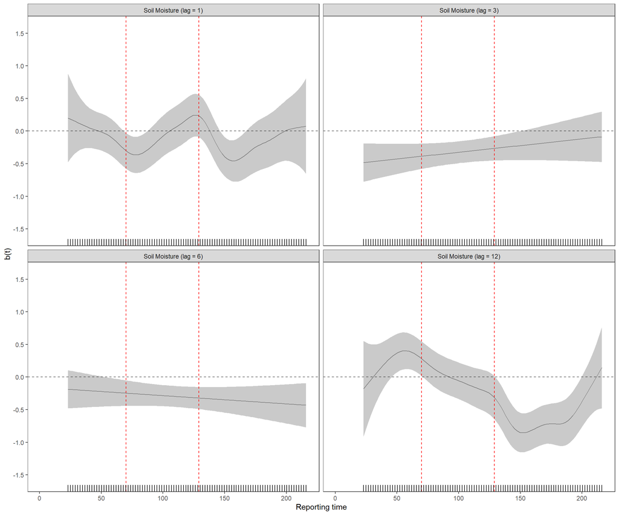

```r
plot_tvcm(plot_vivax_tvcm_l[9:13], vivax_tvcm_l_labels[9:13], vivax_ylim)
```

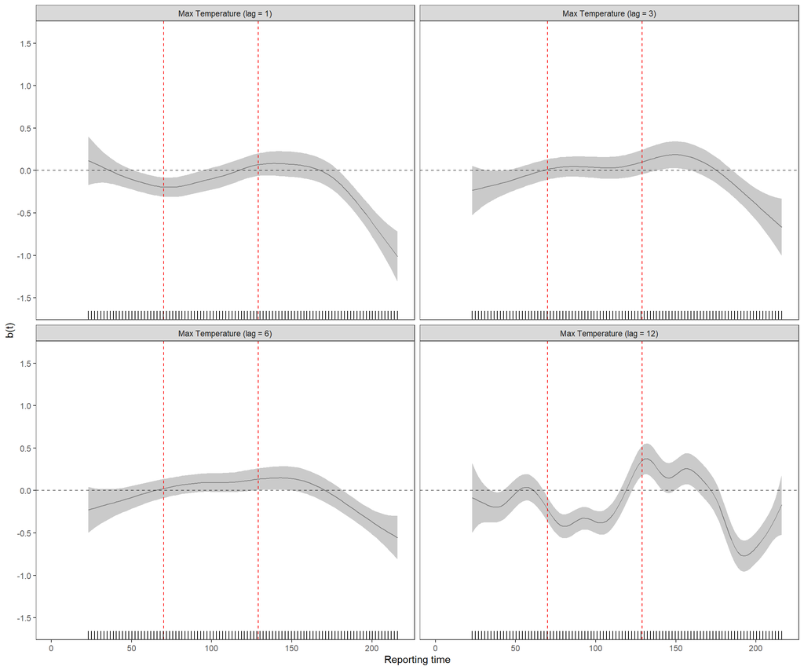

```r
plot_tvcm(plot_vivax_tvcm_l[13:17], vivax_tvcm_l_labels[13:17], vivax_ylim)
```

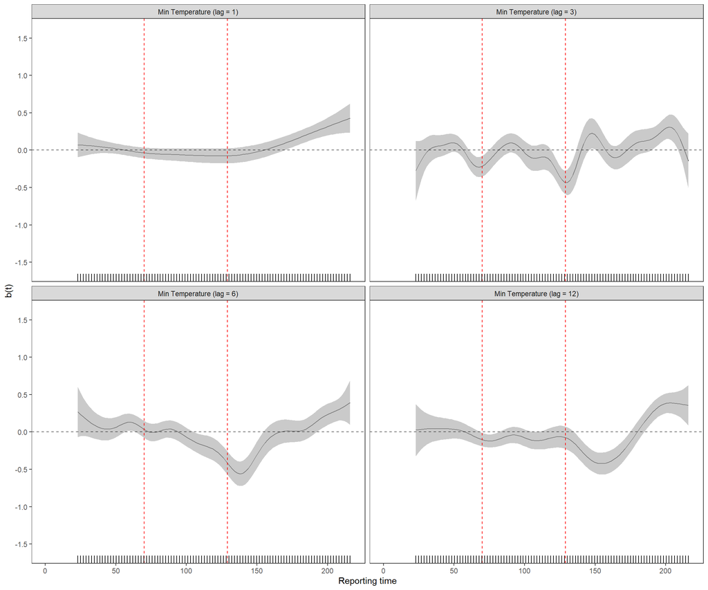

```r
plot_tvcm(plot_vivax_tvcm_l[17:21], vivax_tvcm_l_labels[17:21], vivax_ylim)
```

### Falciparum

Model with no lag features.

```r
tictoc::tic("GAM model fitting")
falciparum_tvcm <- mgcv::bam(
  formula =
    falciparum ~
    offset(log(pop2015)) +
    s(district, bs = "re", k = 49) +
    s(reporting_time, by = aet_std,   bs = "tp", k = 20) +
    s(reporting_time, by = prcp_std,  bs = "tp", k = 20) +
    s(reporting_time, by = soilm_std, bs = "tp", k = 20) +
    s(reporting_time, by = tmax_std,  bs = "tp", k = 20) +
    s(reporting_time, by = tmin_std,  bs = "tp", k = 20),
  family   = nb(),
  data     = dataset,
  method   = "fREML",
  discrete = TRUE
)
tictoc::toc()
```

```
## GAM model fitting: 3.56 sec elapsed
```

```r
falciparum_tvcm$converged
```

```
## [1] TRUE
```

```r
falciparum_tvcm$sp
```

```
##                 s(district)   s(reporting_time):aet_std
##                 0.213814575                 0.011258161
##  s(reporting_time):prcp_std s(reporting_time):soilm_std
##                 0.012107087                 0.003382255
##  s(reporting_time):tmax_std  s(reporting_time):tmin_std
##                 0.124911039                 0.076578064
```

```r
summary.gam(falciparum_tvcm)
```

```
##
## Family: Negative Binomial(0.481)
## Link function: log
##
## Formula:
## falciparum ~ offset(log(pop2015)) + s(district, bs = "re", k = 49) +
##     s(reporting_time, by = aet_std, bs = "tp", k = 20) + s(reporting_time,
##     by = prcp_std, bs = "tp", k = 20) + s(reporting_time, by = soilm_std,
##     bs = "tp", k = 20) + s(reporting_time, by = tmax_std, bs = "tp",
##     k = 20) + s(reporting_time, by = tmin_std, bs = "tp", k = 20)
##
## Parametric coefficients:
##             Estimate Std. Error t value Pr(>|t|)
## (Intercept)  -8.7289     0.3111  -28.06   <2e-16 ***
## ---
## Signif. codes:  0 '***' 0.001 '**' 0.01 '*' 0.05 '.' 0.1 ' ' 1
##
## Approximate significance of smooth terms:
##                                edf Ref.df       F  p-value
## s(district)                 47.297  48.00 175.208  < 2e-16 ***
## s(reporting_time):aet_std   15.184  17.36   8.173  < 2e-16 ***
## s(reporting_time):prcp_std  14.726  16.93   5.955  < 2e-16 ***
## s(reporting_time):soilm_std 16.736  18.67  15.605  < 2e-16 ***
## s(reporting_time):tmax_std   8.665  10.42  16.555  < 2e-16 ***
## s(reporting_time):tmin_std  10.069  12.07   3.637 1.58e-05 ***
## ---
## Signif. codes:  0 '***' 0.001 '**' 0.01 '*' 0.05 '.' 0.1 ' ' 1
##
## R-sq.(adj) =   0.39   Deviance explained = 63.2%
## fREML =  14527  Scale est. = 1         n = 10584
```

```r
falciparum_tvcm$aic
```

```
## [1] 49226.62
```

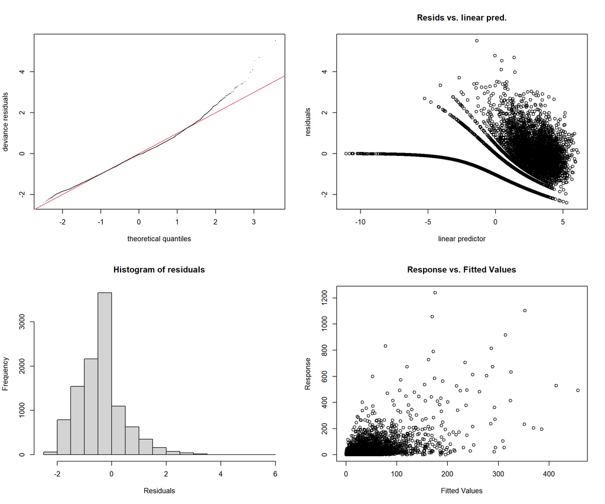

```
##
## Method: fREML   Optimizer: perf chol
## $grad
## [1] 3.374916e-07 7.392740e-08 3.163322e-08 1.428946e-07 3.896869e-08
## [6] 6.424789e-08
##
## $hess
##              [,1]         [,2]        [,3]        [,4]        [,5]         [,6]
## [1,] 21.519146916 -0.006971776  0.23407607 -0.07857322 -0.07118503 -0.069363974
## [2,] -0.006971776  3.297208044 -0.19033076  0.12061062  0.22703274  0.006765718
## [3,]  0.234076074 -0.190330759  2.69874961 -0.01575718 -0.13469632 -0.201357128
## [4,] -0.078573225  0.120610624 -0.01575718  4.67958857  0.11673917  0.121039492
## [5,] -0.071185025  0.227032743 -0.13469632  0.11673917  1.33812661 -0.188455116
## [6,] -0.069363974  0.006765718 -0.20135713  0.12103949 -0.18845512  1.463681084
##
## Model rank =  150 / 150
##
## Basis dimension (k) checking results. Low p-value (k-index<1) may
## indicate that k is too low, especially if edf is close to k'.
##
##                                k'   edf k-index p-value
## s(district)                 49.00 47.30      NA      NA
## s(reporting_time):aet_std   20.00 15.18    0.76  <2e-16 ***
## s(reporting_time):prcp_std  20.00 14.73    0.76  <2e-16 ***
## s(reporting_time):soilm_std 20.00 16.74    0.76  <2e-16 ***
## s(reporting_time):tmax_std  20.00  8.67    0.76  <2e-16 ***
## s(reporting_time):tmin_std  20.00 10.07    0.76  <2e-16 ***
## ---
## Signif. codes:  0 '***' 0.001 '**' 0.01 '*' 0.05 '.' 0.1 ' ' 1
```

```r
gam.check(falciparum_tvcm)
```

Distributed lag models

Model with lag = 1 month.

```r
tictoc::tic("GAM model fitting")
falciparum_tvcm_l01 <- mgcv::bam(
  formula =
    falciparum ~
    offset(log(pop2015)) +
    s(district, bs = "re") +
    s(reporting_time, by = aet_l01,   bs = "tp", k = 20) +
    s(reporting_time, by = prcp_l01,  bs = "tp", k = 20) +
    s(reporting_time, by = soilm_l01, bs = "tp", k = 20) +
    s(reporting_time, by = tmax_l01,  bs = "tp", k = 20) +
    s(reporting_time, by = tmin_l01,  bs = "tp", k = 20),
  family   = nb(),
  data     = dataset[!is.na(dataset$soilm_l01), ],
  method   = "fREML",
  discrete = TRUE
)
tictoc::toc()
```

```
## GAM model fitting: 3.05 sec elapsed
```

```r
falciparum_tvcm_l01$converged
```

```
## [1] TRUE
```

```r
summary.gam(falciparum_tvcm_l01)
```

```
##
## Family: Negative Binomial(0.472)
## Link function: log
##
## Formula:
## falciparum ~ offset(log(pop2015)) + s(district, bs = "re") +
##     s(reporting_time, by = aet_l01, bs = "tp", k = 20) + s(reporting_time,
##     by = prcp_l01, bs = "tp", k = 20) + s(reporting_time, by = soilm_l01,
##     bs = "tp", k = 20) + s(reporting_time, by = tmax_l01, bs = "tp",
##     k = 20) + s(reporting_time, by = tmin_l01, bs = "tp", k = 20)
##
## Parametric coefficients:
##             Estimate Std. Error t value Pr(>|t|)
## (Intercept)  -8.7019     0.3285  -26.49   <2e-16 ***
## ---
## Signif. codes:  0 '***' 0.001 '**' 0.01 '*' 0.05 '.' 0.1 ' ' 1
##
## Approximate significance of smooth terms:
##                                edf Ref.df       F p-value
## s(district)                 47.356  48.00 173.343 < 2e-16 ***
## s(reporting_time):aet_l01   14.119  16.41   9.949 < 2e-16 ***
## s(reporting_time):prcp_l01  12.183  14.42   4.453 < 2e-16 ***
## s(reporting_time):soilm_l01 17.111  18.94  19.541 < 2e-16 ***
## s(reporting_time):tmax_l01   8.642  10.42  13.848 < 2e-16 ***
## s(reporting_time):tmin_l01   2.000   2.00   9.231 9.9e-05 ***
## ---
## Signif. codes:  0 '***' 0.001 '**' 0.01 '*' 0.05 '.' 0.1 ' ' 1
##
## R-sq.(adj) =  0.358   Deviance explained = 62.6%
## fREML =  14450  Scale est. = 1         n = 10535
```

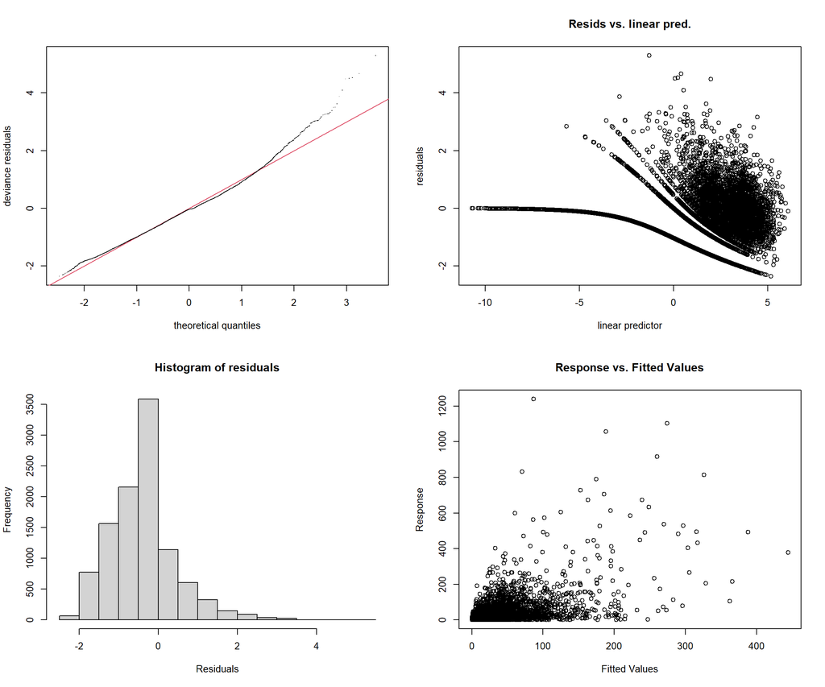

```
##
## Method: fREML   Optimizer: perf chol
## $grad
## [1] -1.686571e-07 -2.101837e-07 -1.425610e-07 -1.590881e-07 -1.092961e-07
## [6] -5.984345e-05
##
## $hess
##               [,1]          [,2]          [,3]          [,4]          [,5]
## [1,]  2.113703e+01 -3.159600e-02  2.471889e-01 -0.0869284279 -8.294270e-02
## [2,] -3.159600e-02  1.916081e+00 -1.629166e-01  0.1966314434  3.783095e-02
## [3,]  2.471889e-01 -1.629166e-01  6.104565e-01 -0.1785828576 -4.110378e-02
## [4,] -8.692843e-02  1.966314e-01 -1.785829e-01  5.3192314964  9.142389e-02
## [5,] -8.294270e-02  3.783095e-02 -4.110378e-02  0.0914238950  1.034374e+00
## [6,] -2.909004e-07  7.392593e-08  3.620719e-07 -0.0000038608 -4.887444e-07
##               [,6]
## [1,] -2.909004e-07
## [2,]  7.392593e-08
## [3,]  3.620719e-07
## [4,] -3.860800e-06
## [5,] -4.887444e-07
## [6,]  5.982691e-05
##
## Model rank =  150 / 150
##
## Basis dimension (k) checking results. Low p-value (k-index<1) may
## indicate that k is too low, especially if edf is close to k'.
##
##                                k'   edf k-index p-value
## s(district)                 49.00 47.36      NA      NA
## s(reporting_time):aet_l01   20.00 14.12    0.76  <2e-16 ***
## s(reporting_time):prcp_l01  20.00 12.18    0.76  <2e-16 ***
## s(reporting_time):soilm_l01 20.00 17.11    0.76  <2e-16 ***
## s(reporting_time):tmax_l01  20.00  8.64    0.76  <2e-16 ***
## s(reporting_time):tmin_l01  20.00  2.00    0.76  <2e-16 ***
## ---
## Signif. codes:  0 '***' 0.001 '**' 0.01 '*' 0.05 '.' 0.1 ' ' 1
```

```r
gam.check(falciparum_tvcm_l01)
```

```r
falciparum_tvcm_l01$aic
```

```
## [1] 49103.88
```

Model with lag = 3 months.

```r
tictoc::tic("GAM model fitting")
falciparum_tvcm_l03 <- mgcv::bam(
  formula =
    falciparum ~
    offset(log(pop2015)) +
    s(district, bs = "re") +
    s(reporting_time, by = aet_l03,   bs = "tp", k = 20) +
    s(reporting_time, by = prcp_l03,  bs = "tp", k = 20) +
    s(reporting_time, by = soilm_l03, bs = "tp", k = 20) +
    s(reporting_time, by = tmax_l03,  bs = "tp", k = 20) +
    s(reporting_time, by = tmin_l03,  bs = "tp", k = 20),
  family   = nb(),
  data     = dataset[!is.na(dataset$soilm_l03), ],
  method   = "fREML",
  discrete = TRUE
)
tictoc::toc()
```

```
## GAM model fitting: 3.23 sec elapsed
```

```r
falciparum_tvcm_l03$converged
```

```
## [1] TRUE
```

```r
summary.gam(falciparum_tvcm_l03)
```

```
##
## Family: Negative Binomial(0.487)
## Link function: log
##
## Formula:
## falciparum ~ offset(log(pop2015)) + s(district, bs = "re") +
##     s(reporting_time, by = aet_l03, bs = "tp", k = 20) + s(reporting_time,
##     by = prcp_l03, bs = "tp", k = 20) + s(reporting_time, by = soilm_l03,
##     bs = "tp", k = 20) + s(reporting_time, by = tmax_l03, bs = "tp",
##     k = 20) + s(reporting_time, by = tmin_l03, bs = "tp", k = 20)
##
## Parametric coefficients:
##             Estimate Std. Error t value Pr(>|t|)
## (Intercept)  -8.6528     0.3504  -24.69   <2e-16 ***
## ---
## Signif. codes:  0 '***' 0.001 '**' 0.01 '*' 0.05 '.' 0.1 ' ' 1
##
## Approximate significance of smooth terms:
##                               edf Ref.df       F p-value
## s(district)                 47.42  49.00 173.846  <2e-16 ***
## s(reporting_time):aet_l03   12.31  14.58  15.755  <2e-16 ***
## s(reporting_time):prcp_l03  12.44  14.65  13.735  <2e-16 ***
## s(reporting_time):soilm_l03 15.19  17.41  13.244  <2e-16 ***
## s(reporting_time):tmax_l03  10.23  12.21  12.393  <2e-16 ***
## s(reporting_time):tmin_l03  17.37  19.00   9.385  <2e-16 ***
## ---
## Signif. codes:  0 '***' 0.001 '**' 0.01 '*' 0.05 '.' 0.1 ' ' 1
##
## R-sq.(adj) =  0.361   Deviance explained = 63.7%
## fREML =  14328  Scale est. = 1         n = 10437
```

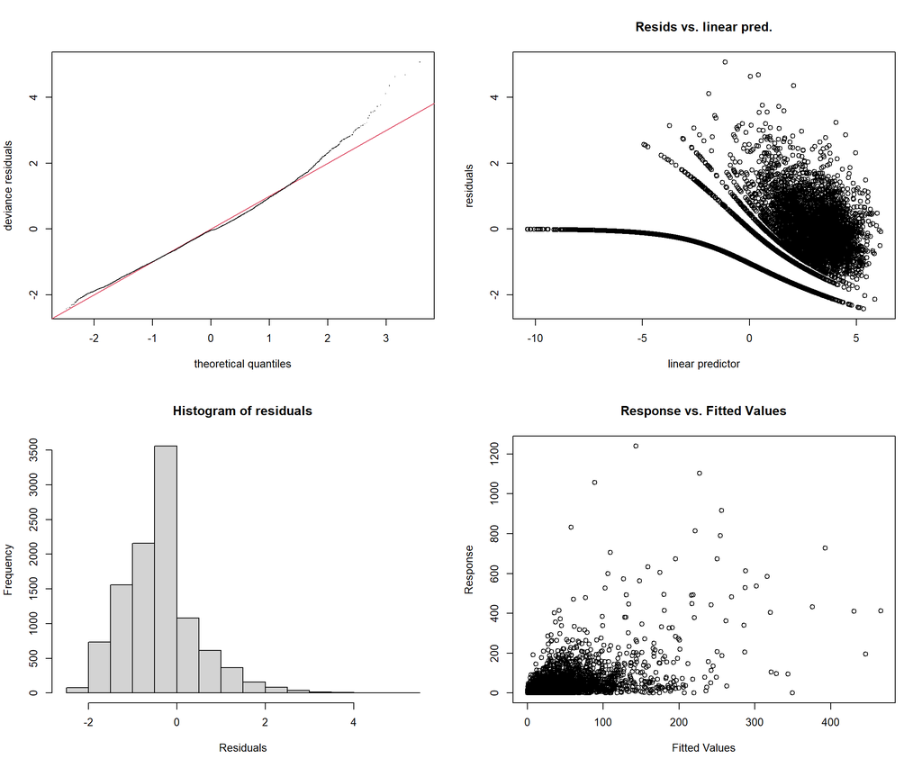

```
##
## Method: fREML   Optimizer: perf chol
## $grad
## [1]  3.250321e-07  1.300391e-08 -4.770307e-08  9.418093e-08 -1.842094e-08
## [6] -3.032815e-08
##
## $hess
##              [,1]         [,2]        [,3]        [,4]        [,5]        [,6]
## [1,] 21.114231731  0.007133277  0.07863842 -0.11049570 -0.10492251 -0.25751912
## [2,]  0.007133277  1.600157543 -0.03617652  0.26554921  0.23720221 -0.04567580
## [3,]  0.078638420 -0.036176521  3.35601621 -0.13167160 -0.16647744 -0.08085249
## [4,] -0.110495701  0.265549214 -0.13167160  3.61312128  0.40842264  0.07192263
## [5,] -0.104922507  0.237202209 -0.16647744  0.40842264  0.94845937 -0.04587924
## [6,] -0.257519116 -0.045675798 -0.08085249  0.07192263 -0.04587924  5.16473944
##
## Model rank =  150 / 150
##
## Basis dimension (k) checking results. Low p-value (k-index<1) may
## indicate that k is too low, especially if edf is close to k'.
##
##                               k'  edf k-index p-value
## s(district)                 49.0 47.4      NA      NA
## s(reporting_time):aet_l03   20.0 12.3    0.77  <2e-16 ***
## s(reporting_time):prcp_l03  20.0 12.4    0.77  <2e-16 ***
## s(reporting_time):soilm_l03 20.0 15.2    0.77  <2e-16 ***
## s(reporting_time):tmax_l03  20.0 10.2    0.77  <2e-16 ***
## s(reporting_time):tmin_l03  20.0 17.4    0.77  <2e-16 ***
## ---
## Signif. codes:  0 '***' 0.001 '**' 0.01 '*' 0.05 '.' 0.1 ' ' 1
```

```r
gam.check(falciparum_tvcm_l03)
```

```r
falciparum_tvcm_l03$aic
```

```
## [1] 48412.49
```

Model with lag = 6 months.

```r
tictoc::tic("GAM model fitting")
falciparum_tvcm_l06 <- mgcv::bam(
  formula =
    falciparum ~
    offset(log(pop2015)) +
    s(district, bs = "re") +
    s(reporting_time, by = aet_l06,   bs = "tp", k = 20) +
    s(reporting_time, by = prcp_l06,  bs = "tp", k = 20) +
    s(reporting_time, by = soilm_l06, bs = "tp", k = 20) +
    s(reporting_time, by = tmax_l06,  bs = "tp", k = 20) +
    s(reporting_time, by = tmin_l06,  bs = "tp", k = 20),
  family   = nb(),
  data     = dataset[!is.na(dataset$soilm_l06), ],
  method   = "fREML",
  discrete = TRUE
)
tictoc::toc()
```

```
## GAM model fitting: 3.25 sec elapsed
```

```r
falciparum_tvcm_l06$converged
```

```
## [1] TRUE
```

```r
summary.gam(falciparum_tvcm_l06)
```

```
##
## Family: Negative Binomial(0.473)
## Link function: log
##
## Formula:
## falciparum ~ offset(log(pop2015)) + s(district, bs = "re") +
##     s(reporting_time, by = aet_l06, bs = "tp", k = 20) + s(reporting_time,
##     by = prcp_l06, bs = "tp", k = 20) + s(reporting_time, by = soilm_l06,
##     bs = "tp", k = 20) + s(reporting_time, by = tmax_l06, bs = "tp",
##     k = 20) + s(reporting_time, by = tmin_l06, bs = "tp", k = 20)
##
## Parametric coefficients:
##             Estimate Std. Error t value Pr(>|t|)
## (Intercept)  -8.6007     0.3841  -22.39   <2e-16 ***
## ---
## Signif. codes:  0 '***' 0.001 '**' 0.01 '*' 0.05 '.' 0.1 ' ' 1
##
## Approximate significance of smooth terms:
##                               edf Ref.df       F p-value
## s(district)                 47.48  49.00 158.370  <2e-16 ***
## s(reporting_time):aet_l06   14.99  17.16   8.469  <2e-16 ***
## s(reporting_time):prcp_l06  11.92  14.12  14.803  <2e-16 ***
## s(reporting_time):soilm_l06 13.96  16.23  12.547  <2e-16 ***
## s(reporting_time):tmax_l06  17.79  19.11   8.820  <2e-16 ***
## s(reporting_time):tmin_l06  14.35  16.58   4.833  <2e-16 ***
## ---
## Signif. codes:  0 '***' 0.001 '**' 0.01 '*' 0.05 '.' 0.1 ' ' 1
##
## R-sq.(adj) =  0.358   Deviance explained = 63.4%
## fREML =  13498  Scale est. = 1         n = 9800
```

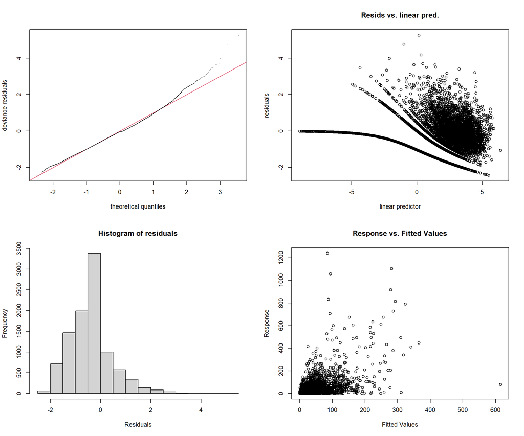

```
##
## Method: fREML   Optimizer: perf chol
## $grad
## [1] -2.011467e-07 -2.956015e-07 -4.096984e-08 -3.447021e-07 -3.029110e-07
## [6] -2.484206e-07
##
## $hess
##             [,1]        [,2]        [,3]        [,4]        [,5]        [,6]
## [1,] 20.41137022  0.05304765  0.15385172 -0.17856663  0.06644733 -0.06628551
## [2,]  0.05304765  2.90844408 -0.13151701 -0.24862825  0.27375064 -0.03955542
## [3,]  0.15385172 -0.13151701  2.96630379 -0.05315728 -0.12524468 -0.13526089
## [4,] -0.17856663 -0.24862825 -0.05315728  3.58827201 -0.35463572  0.60877298
## [5,]  0.06644733  0.27375064 -0.12524468 -0.35463572  3.93213020  0.23096901
## [6,] -0.06628551 -0.03955542 -0.13526089  0.60877298  0.23096901  2.07150245
##
## Model rank =  150 / 150
##
## Basis dimension (k) checking results. Low p-value (k-index<1) may
## indicate that k is too low, especially if edf is close to k'.
##
##                               k'  edf k-index p-value
## s(district)                 49.0 47.5      NA      NA
## s(reporting_time):aet_l06   20.0 15.0    0.76  <2e-16 ***
## s(reporting_time):prcp_l06  20.0 11.9    0.76  <2e-16 ***
## s(reporting_time):soilm_l06 20.0 14.0    0.76  <2e-16 ***
## s(reporting_time):tmax_l06  20.0 17.8    0.76  <2e-16 ***
## s(reporting_time):tmin_l06  20.0 14.4    0.76  <2e-16 ***
## ---
## Signif. codes:  0 '***' 0.001 '**' 0.01 '*' 0.05 '.' 0.1 ' ' 1
```

```r
gam.check(falciparum_tvcm_l06)
```

```r
falciparum_tvcm_l06$aic
```

```
## [1] 45707.11
```

Model with lag = 12 months.

```r
tictoc::tic("GAM model fitting")
falciparum_tvcm_l12 <- mgcv::bam(
  formula =
    falciparum ~
    offset(log(pop2015)) +
    s(district, bs = "re") +
    s(reporting_time, by = aet_l12,   bs = "tp", k = 20) +
    s(reporting_time, by = prcp_l12,  bs = "tp", k = 20) +
    s(reporting_time, by = soilm_l12, bs = "tp", k = 20) +
    s(reporting_time, by = tmax_l12,  bs = "tp", k = 20) +
    s(reporting_time, by = tmin_l12,  bs = "tp", k = 20),
  family   = nb(),
  data     = dataset[!is.na(dataset$soilm_l12), ],
  method   = "fREML",
  discrete = TRUE
)
tictoc::toc()
```

```
## GAM model fitting: 3.2 sec elapsed
```

```r
falciparum_tvcm_l12$converged
```

```
## [1] TRUE
```

```r
summary.gam(falciparum_tvcm_l12)
```

```
##
## Family: Negative Binomial(0.477)
## Link function: log
##
## Formula:
## falciparum ~ offset(log(pop2015)) + s(district, bs = "re") +
##     s(reporting_time, by = aet_l12, bs = "tp", k = 20) + s(reporting_time,
##     by = prcp_l12, bs = "tp", k = 20) + s(reporting_time, by = soilm_l12,
##     bs = "tp", k = 20) + s(reporting_time, by = tmax_l12, bs = "tp",
##     k = 20) + s(reporting_time, by = tmin_l12, bs = "tp", k = 20)
##
## Parametric coefficients:
##             Estimate Std. Error t value Pr(>|t|)
## (Intercept)  -8.7052     0.3487  -24.96   <2e-16 ***
## ---
## Signif. codes:  0 '***' 0.001 '**' 0.01 '*' 0.05 '.' 0.1 ' ' 1
##
## Approximate significance of smooth terms:
##                                edf Ref.df       F p-value
## s(district)                 47.393 48.000 158.796  <2e-16 ***
## s(reporting_time):aet_l12   17.418 19.065   6.722  <2e-16 ***
## s(reporting_time):prcp_l12  12.029 14.253   7.734  <2e-16 ***
## s(reporting_time):soilm_l12 14.524 16.810  14.958  <2e-16 ***
## s(reporting_time):tmax_l12   8.318  9.984  20.541  <2e-16 ***
## s(reporting_time):tmin_l12  13.763 16.048   8.275  <2e-16 ***
## ---
## Signif. codes:  0 '***' 0.001 '**' 0.01 '*' 0.05 '.' 0.1 ' ' 1
##
## R-sq.(adj) =  0.391   Deviance explained = 63.9%
## fREML =  13077  Scale est. = 1         n = 9506
```

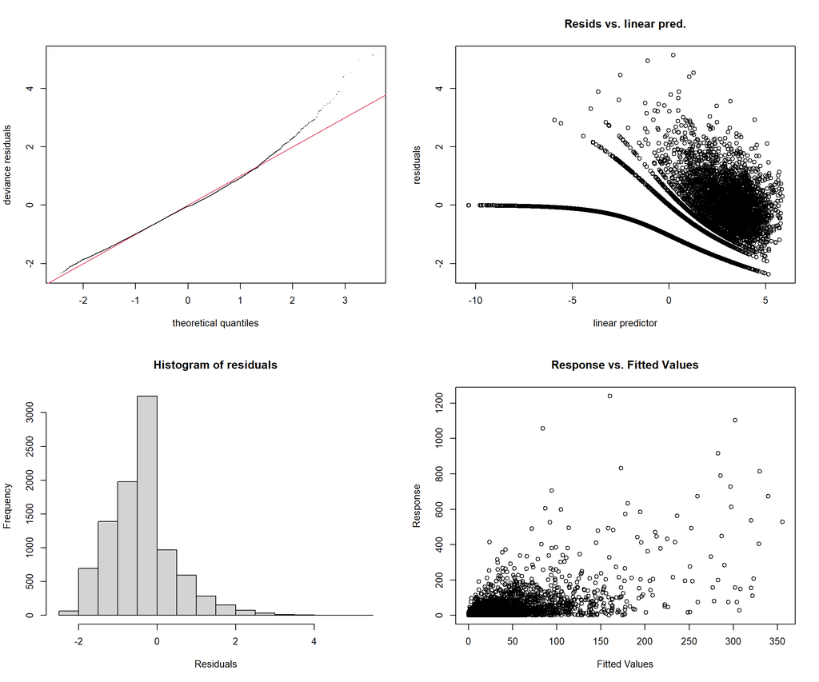

```
##
## Method: fREML   Optimizer: perf chol
## $grad
## [1] 1.198252e-07 8.427085e-08 2.944417e-08 9.769236e-08 2.041157e-08
## [6] 6.244520e-08
##
## $hess
##             [,1]        [,2]        [,3]        [,4]        [,5]       [,6]
## [1,] 20.74794787  0.12217618  0.01343805 -0.21720942 -0.06500987 -0.0907787
## [2,]  0.12217618  3.62526498  0.11337598  0.00799638 -0.02760001 -0.2066178
## [3,]  0.01343805  0.11337598  2.73783479 -0.22111355  0.06326202 -0.1961144
## [4,] -0.21720942  0.00799638 -0.22111355  3.28417188  0.07784155 -0.4073493
## [5,] -0.06500987 -0.02760001  0.06326202  0.07784155  1.79010151  0.1561181
## [6,] -0.09077870 -0.20661782 -0.19611436 -0.40734932  0.15611810  2.6533808
##
## Model rank =  150 / 150
##
## Basis dimension (k) checking results. Low p-value (k-index<1) may
## indicate that k is too low, especially if edf is close to k'.
##
##                                k'   edf k-index p-value
## s(district)                 49.00 47.39      NA      NA
## s(reporting_time):aet_l12   20.00 17.42    0.77  <2e-16 ***
## s(reporting_time):prcp_l12  20.00 12.03    0.77  <2e-16 ***
## s(reporting_time):soilm_l12 20.00 14.52    0.77  <2e-16 ***
## s(reporting_time):tmax_l12  20.00  8.32    0.77  <2e-16 ***
## s(reporting_time):tmin_l12  20.00 13.76    0.77  <2e-16 ***
## ---
## Signif. codes:  0 '***' 0.001 '**' 0.01 '*' 0.05 '.' 0.1 ' ' 1
```

```r
gam.check(falciparum_tvcm_l12)
```

```r
falciparum_tvcm_l12$aic
```

```
## [1] 44223.83
```

Model with all lag features.

```r
tictoc::tic("GAM model fitting")
falciparum_tvcm_l <- mgcv::bam(
  formula =
    falciparum ~
    offset(log(pop2015)) +
    s(district, bs = "re") +
    s(reporting_time, by = aet_l01,   bs = "tp", k = 20) +
    s(reporting_time, by = aet_l03,   bs = "tp", k = 20) +
    s(reporting_time, by = aet_l06,   bs = "tp", k = 20) +
    s(reporting_time, by = aet_l12,   bs = "tp", k = 20) +
    s(reporting_time, by = prcp_l01,  bs = "tp", k = 20) +
    s(reporting_time, by = prcp_l03,  bs = "tp", k = 20) +
    s(reporting_time, by = prcp_l06,  bs = "tp", k = 20) +
    s(reporting_time, by = prcp_l12,  bs = "tp", k = 20) +
    s(reporting_time, by = soilm_l01, bs = "tp", k = 20) +
    s(reporting_time, by = soilm_l03, bs = "tp", k = 20) +
    s(reporting_time, by = soilm_l06, bs = "tp", k = 20) +
    s(reporting_time, by = soilm_l12, bs = "tp", k = 20) +
    s(reporting_time, by = tmax_l01,  bs = "tp", k = 20) +
    s(reporting_time, by = tmax_l03,  bs = "tp", k = 20) +
    s(reporting_time, by = tmax_l06,  bs = "tp", k = 20) +
    s(reporting_time, by = tmax_l12,  bs = "tp", k = 20) +
    s(reporting_time, by = tmin_l01,  bs = "tp", k = 20) +
    s(reporting_time, by = tmin_l03,  bs = "tp", k = 20) +
    s(reporting_time, by = tmin_l06,  bs = "tp", k = 20) +
    s(reporting_time, by = tmin_l12,  bs = "tp", k = 20),
  family   = nb(),
  data     = dataset[!is.na(dataset$soilm_l12), ],
  method   = "fREML",
  discrete = TRUE
)
tictoc::toc()
```

```
## GAM model fitting: 15.67 sec elapsed
```

```r
falciparum_tvcm_l$converged
```

```
## [1] TRUE
```

```r
summary.gam(falciparum_tvcm_l)
```

```
##
## Family: Negative Binomial(0.577)
## Link function: log
##
## Formula:
## falciparum ~ offset(log(pop2015)) + s(district, bs = "re") +
##     s(reporting_time, by = aet_l01, bs = "tp", k = 20) + s(reporting_time,
##     by = aet_l03, bs = "tp", k = 20) + s(reporting_time, by = aet_l06,
##     bs = "tp", k = 20) + s(reporting_time, by = aet_l12, bs = "tp",
##     k = 20) + s(reporting_time, by = prcp_l01, bs = "tp", k = 20) +
##     s(reporting_time, by = prcp_l03, bs = "tp", k = 20) + s(reporting_time,
##     by = prcp_l06, bs = "tp", k = 20) + s(reporting_time, by = prcp_l12,
##     bs = "tp", k = 20) + s(reporting_time, by = soilm_l01, bs = "tp",
##     k = 20) + s(reporting_time, by = soilm_l03, bs = "tp", k = 20) +
##     s(reporting_time, by = soilm_l06, bs = "tp", k = 20) + s(reporting_time,
##     by = soilm_l12, bs = "tp", k = 20) + s(reporting_time, by = tmax_l01,
##     bs = "tp", k = 20) + s(reporting_time, by = tmax_l03, bs = "tp",
##     k = 20) + s(reporting_time, by = tmax_l06, bs = "tp", k = 20) +
##     s(reporting_time, by = tmax_l12, bs = "tp", k = 20) + s(reporting_time,
##     by = tmin_l01, bs = "tp", k = 20) + s(reporting_time, by = tmin_l03,
##     bs = "tp", k = 20) + s(reporting_time, by = tmin_l06, bs = "tp",
##     k = 20) + s(reporting_time, by = tmin_l12, bs = "tp", k = 20)
##
## Parametric coefficients:
##             Estimate Std. Error t value Pr(>|t|)
## (Intercept)  -8.8581     0.3128  -28.32   <2e-16 ***
## ---
## Signif. codes:  0 '***' 0.001 '**' 0.01 '*' 0.05 '.' 0.1 ' ' 1
##
## Approximate significance of smooth terms:
##                                edf Ref.df       F  p-value
## s(district)                 46.919 49.000 164.954  < 2e-16 ***
## s(reporting_time):aet_l01   13.860 15.998   7.740  < 2e-16 ***
## s(reporting_time):aet_l03    7.013  8.394   9.596  < 2e-16 ***
## s(reporting_time):aet_l06    2.000  2.001   0.433  0.64857
## s(reporting_time):aet_l12    2.000  2.000  14.411 1.02e-06 ***
## s(reporting_time):prcp_l01   3.930  4.628   9.894  < 2e-16 ***
## s(reporting_time):prcp_l03   6.905  8.277   4.895 4.03e-06 ***
## s(reporting_time):prcp_l06   9.610 11.478  13.535  < 2e-16 ***
## s(reporting_time):prcp_l12  13.545 15.717   8.489  < 2e-16 ***
## s(reporting_time):soilm_l01 11.482 13.190   3.452 1.81e-05 ***
## s(reporting_time):soilm_l03  3.970  4.636   3.438  0.00573 **
## s(reporting_time):soilm_l06  2.000  2.001   0.570  0.56578
## s(reporting_time):soilm_l12 11.700 13.431   5.819  < 2e-16 ***
## s(reporting_time):tmax_l01   5.864  6.966   7.022  < 2e-16 ***
## s(reporting_time):tmax_l03   7.060  8.425   5.621  < 2e-16 ***
## s(reporting_time):tmax_l06  16.613 18.251   4.570  < 2e-16 ***
## s(reporting_time):tmax_l12   6.797  8.112   9.447  < 2e-16 ***
## s(reporting_time):tmin_l01   5.073  6.034   3.208  0.00369 **
## s(reporting_time):tmin_l03  16.871 18.528   7.562  < 2e-16 ***
## s(reporting_time):tmin_l06  10.986 12.977   4.066  < 2e-16 ***
## s(reporting_time):tmin_l12   9.722 11.571   6.564  < 2e-16 ***
## ---
## Signif. codes:  0 '***' 0.001 '**' 0.01 '*' 0.05 '.' 0.1 ' ' 1
##
## R-sq.(adj) =   0.38   Deviance explained = 69.1%
## fREML =  13266  Scale est. = 1         n = 9506
```

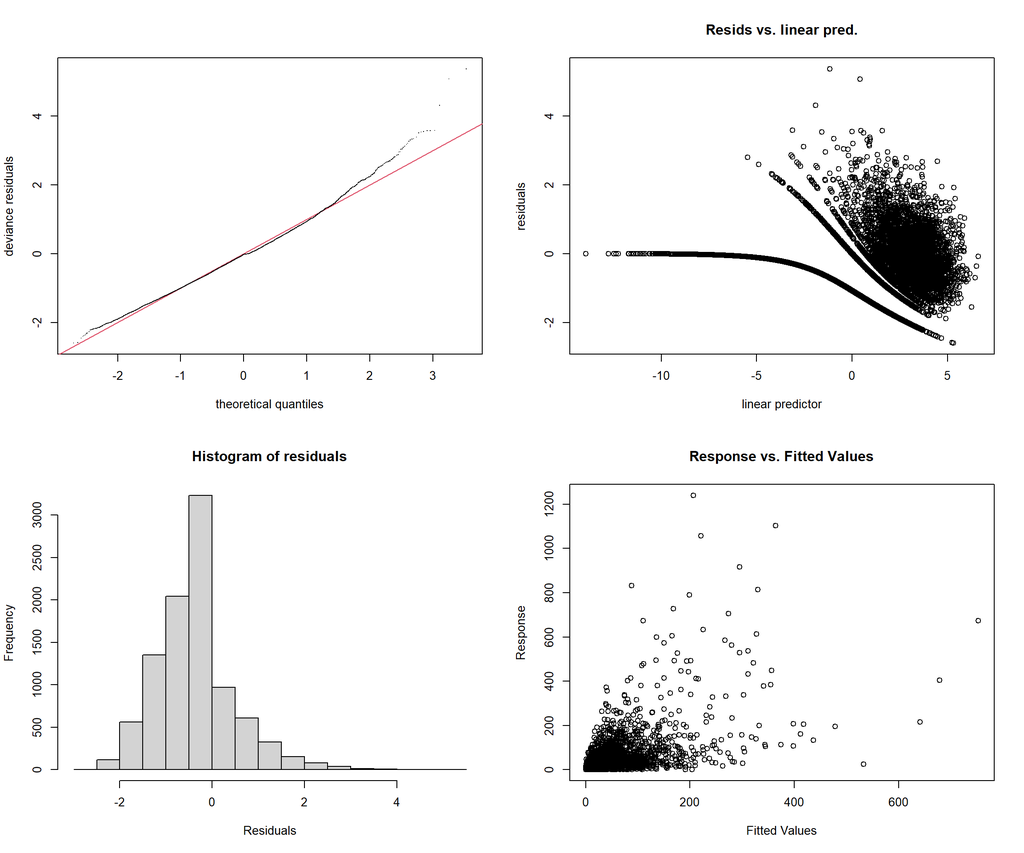

```
##
## Method: fREML   Optimizer: perf chol
## $grad
##  [1] -9.224560e-08 -9.267628e-08 -5.545273e-08 -5.549225e-05 -4.319504e-05
##  [6] -1.833478e-08 -5.003711e-08 -2.533914e-08 -5.418828e-08 -6.597579e-08
## [11] -1.595510e-08 -5.882063e-05 -1.044194e-07 -9.863417e-09 -2.070644e-08
## [16] -1.258910e-07 -1.248591e-08 -3.525105e-08 -4.472750e-08 -1.118826e-07
## [21] -7.112432e-09
##
## $hess
##                [,1]          [,2]          [,3]          [,4]          [,5]
##  [1,]  2.004727e+01 -3.421506e-02  3.759452e-02  3.340519e-06 -1.053037e-05
##  [2,] -3.421506e-02  3.016665e+00  6.931448e-02  2.934701e-05  5.296809e-06
##  [3,]  3.759452e-02  6.931448e-02  1.011701e+00 -3.392312e-06 -2.393874e-06
##  [4,]  3.340519e-06  2.934701e-05 -3.392312e-06  5.548729e-05  1.255498e-09
```

[output cut: 135 more lines]

```r
gam.check(falciparum_tvcm_l)
```

```r
falciparum_tvcm_l$aic
```

```
## [1] 43336.17
```

#### Time-varying coefficients plots

Model with no lag features.

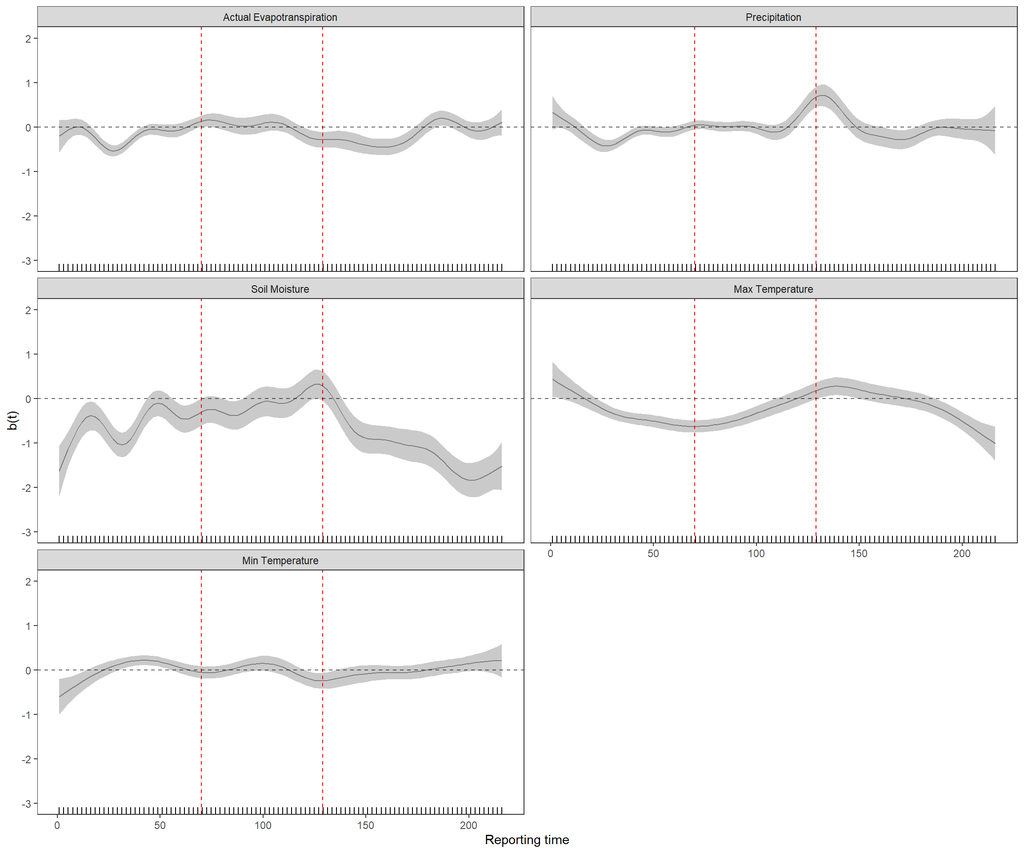

```r
falciparum_ylim <- c(-3, 2)

falciparum_tvcm_labels <- c(
    "Actual Evapotranspiration",
    "Precipitation",
    "Soil Moisture",
    "Max Temperature",
    "Min Temperature"
  )

plot_tvcm(plot_falciparum_tvcm, falciparum_tvcm_labels, falciparum_ylim)
```

Model with lag = 1 month.

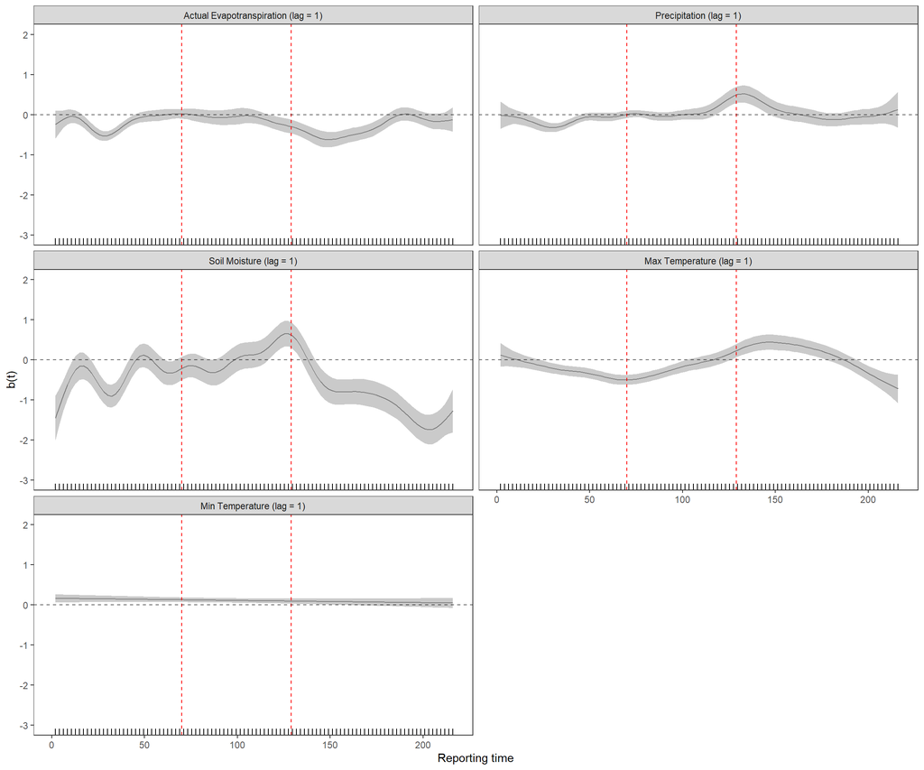

```r
falciparum_tvcm_l01_labels <- c(
    "Actual Evapotranspiration (lag = 1)",
    "Precipitation (lag = 1)",
    "Soil Moisture (lag = 1)",
    "Max Temperature (lag = 1)",
    "Min Temperature (lag = 1)"
  )

plot_tvcm(plot_falciparum_tvcm_l01, falciparum_tvcm_l01_labels, falciparum_ylim)
```

Model with lag = 3 months.

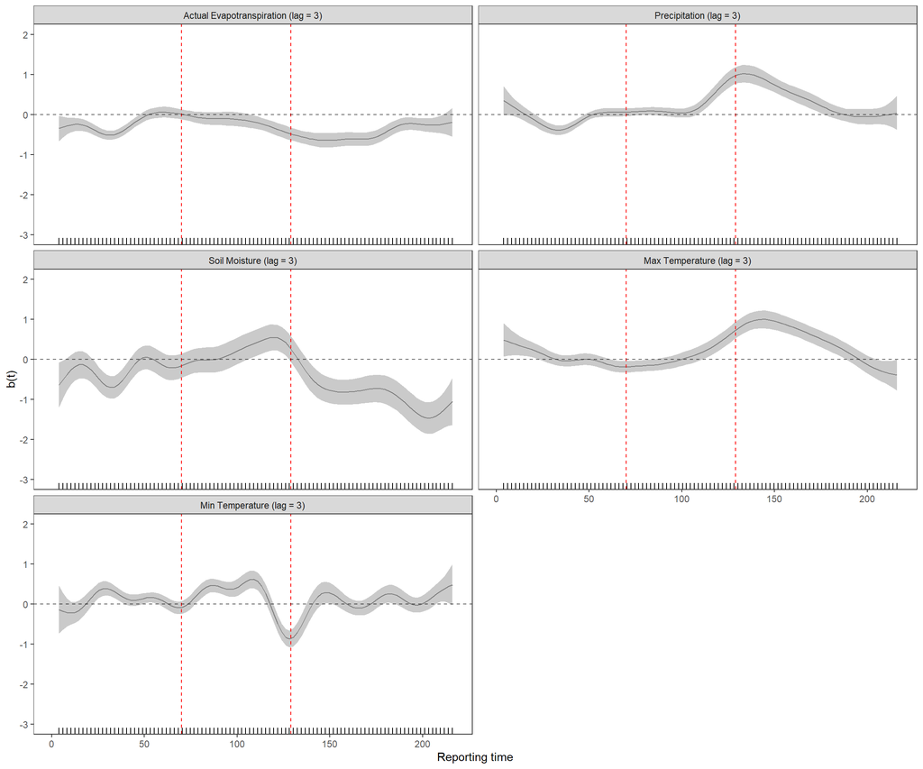

```r
falciparum_tvcm_l03_labels <- c(
    "Actual Evapotranspiration (lag = 3)",
    "Precipitation (lag = 3)",
    "Soil Moisture (lag = 3)",
    "Max Temperature (lag = 3)",
    "Min Temperature (lag = 3)"
  )

plot_tvcm(plot_falciparum_tvcm_l03, falciparum_tvcm_l03_labels, falciparum_ylim)
```

Model with lag = 6 months.

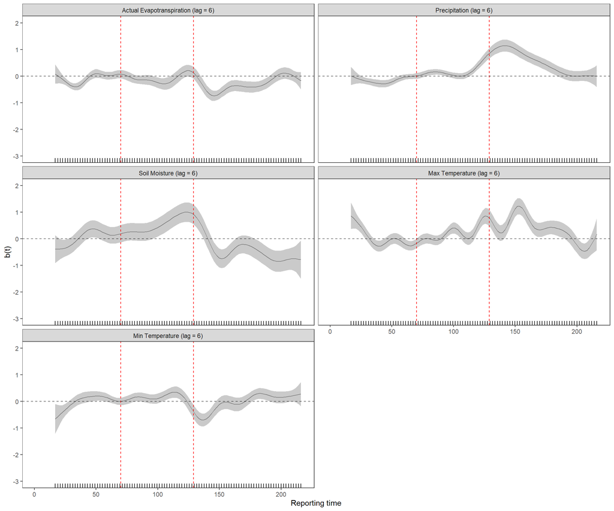

```r
falciparum_tvcm_l06_labels <- c(
    "Actual Evapotranspiration (lag = 6)",
    "Precipitation (lag = 6)",
    "Soil Moisture (lag = 6)",
    "Max Temperature (lag = 6)",
    "Min Temperature (lag = 6)"
  )

plot_tvcm(plot_falciparum_tvcm_l06, falciparum_tvcm_l06_labels, falciparum_ylim)
```

Model with lag = 12 months.

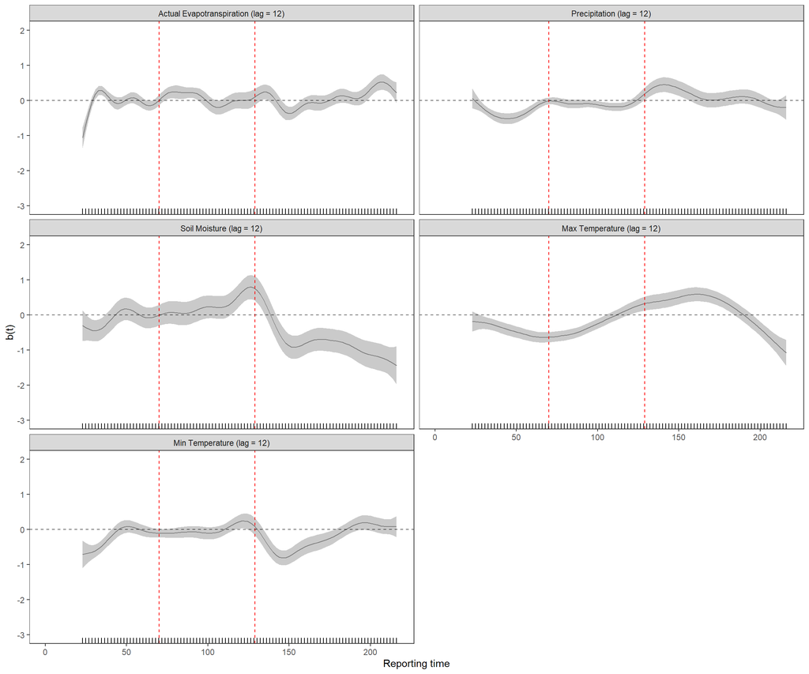

```r
falciparum_tvcm_l12_labels <- c(
    "Actual Evapotranspiration (lag = 12)",
    "Precipitation (lag = 12)",
    "Soil Moisture (lag = 12)",
    "Max Temperature (lag = 12)",
    "Min Temperature (lag = 12)"
  )

plot_tvcm(plot_falciparum_tvcm_l12, falciparum_tvcm_l12_labels, falciparum_ylim)
```

Model with all lag features.

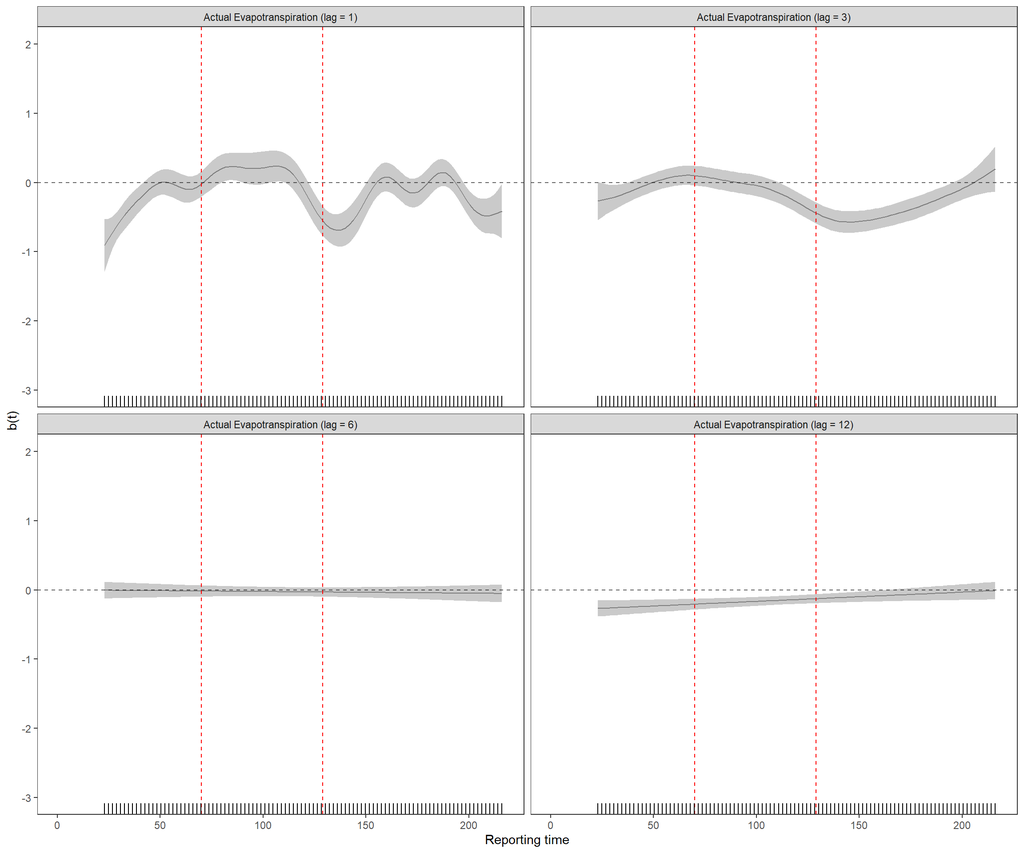

```r
falciparum_tvcm_l_labels <- c(
    "Actual Evapotranspiration (lag = 1)",
    "Actual Evapotranspiration (lag = 3)",
    "Actual Evapotranspiration (lag = 6)",
    "Actual Evapotranspiration (lag = 12)",
    "Precipitation (lag = 1)",
    "Precipitation (lag = 3)",
    "Precipitation (lag = 6)",
    "Precipitation (lag = 12)",
    "Soil Moisture (lag = 1)",
    "Soil Moisture (lag = 3)",
    "Soil Moisture (lag = 6)",
    "Soil Moisture (lag = 12)",
    "Max Temperature (lag = 1)",
    "Max Temperature (lag = 3)",
    "Max Temperature (lag = 6)",
    "Max Temperature (lag = 12)",
    "Min Temperature (lag = 1)",
    "Min Temperature (lag = 3)",
    "Min Temperature (lag = 6)",
    "Min Temperature (lag = 12)"
  )

plot_tvcm(plot_falciparum_tvcm_l[1:5], falciparum_tvcm_l_labels[1:5], falciparum_ylim)
```